# ALL ANSWERS OF THE HOMEWORK

RAN Deng

2024-12-09

# 第一次作业

## 第一个例子

HOI4(13.2)中不同地形的地块数量

录入数据

```r
data<-data.frame(
  terrian = c("forest","hills", "plains", "mountain", "marsh", "urban", "deserts", "jungle","sum"),           ##不同地形&总和
  num = c(2417,1342,3021,1699,136,240,690,400,9945)        ##对应数量
)
```

生成表格

The number of the land parcels with diffent terrains

| terrian | num |
| --- | --- |
| forest | 2417 |
| hills | 1342 |
| plains | 3021 |
| mountain | 1699 |
| marsh | 136 |
| urban | 240 |
| deserts | 690 |
| jungle | 400 |
| sum | 9945 |

## 第二个例子

合肥市历年常住人口数（2003-2023）

录入数据

```r
num <- c(459.53,443,463,468,491,501,510,570.8,752.08,757.2,761.14,769.58,778.95,786.9,796.53,808.74,818.9,936.99,946.5,963.4,985.3)                                                               ##具体人口数据，单位（万人）
year <- (2003:2023)                         ##对应年份
data<-data.frame(year,num)
```

生成表格

合肥市2003-2023年常住人口数（单位：万人）

| year | num |
| --- | --- |
| 2003 | 459.53 |
| 2004 | 443.00 |
| 2005 | 463.00 |
| 2006 | 468.00 |
| 2007 | 491.00 |
| 2008 | 501.00 |
| 2009 | 510.00 |
| 2010 | 570.80 |
| 2011 | 752.08 |
| 2012 | 757.20 |
| 2013 | 761.14 |
| 2014 | 769.58 |
| 2015 | 778.95 |
| 2016 | 786.90 |
| 2017 | 796.53 |
| 2018 | 808.74 |
| 2019 | 818.90 |
| 2020 | 936.99 |
| 2021 | 946.50 |
| 2022 | 963.40 |
| 2023 | 985.30 |

## 第三个例子

生成一组正态分布数字

生成数据并计算数据的平均数和方差

```r
r <- rnorm(200, mean = 0, sd = 1)
mean.r <- mean(r)                       ##求平均数
variance.r <- var(r)                    ##求方差
mean.r
```

```
## [1] 0.06520702
```

```r
variance.r
```

```
## [1] 0.9048382
```

生成表格

| y | r |
| --- | --- |
| 1 | -1.8291098 |
| 2 | -0.5634675 |
| 3 | -0.9071777 |
| 4 | -1.5102991 |
| 5 | 0.1769620 |
| 6 | 0.7160215 |
| 7 | 0.5468654 |
| 8 | -0.8777830 |
| 9 | -0.4678682 |
| 10 | 1.2225079 |
| 11 | 0.2948735 |
| 12 | -1.2774456 |
| 13 | 1.4002089 |
| 14 | -0.0539761 |
| 15 | 1.7802983 |
| 16 | 1.1259583 |
| 17 | -0.6952268 |
| 18 | -0.0847065 |
| 19 | -0.6512118 |
| 20 | 0.2707428 |
| 21 | -0.9433465 |
| 22 | -0.7498491 |
| 23 | -0.5505473 |
| 24 | -1.2565806 |
| 25 | -0.3196460 |
| 26 | 0.7046319 |
| 27 | 0.5745787 |
| 28 | 0.3626928 |
| 29 | 0.1214019 |
| 30 | 2.5657805 |

[output cut: 170 more lines]

画出生成数据的直方图并与理论正态分布曲线比较

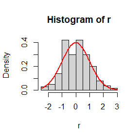

# 第二次作业

## 第一题（3.4）

用逆变换法生成服从Rayleigh(σ)分布的随机变量。 由其概率密度函数$f(x)=x/σ^2*e^{-x^2/(2*σ^2)},x\geq0,σ>0$,可以得到其概率分布函数$F(x)=1-e^{-x^2/(2σ^2)},x\geq0,σ>0$,从而得到$F^{-1}(u)=σ*\sqrt{-2*log(1-u)}$。而$u$与$1-u$均服从$U（0，1）$，故可用$x=F^{-1}(u)=σ*\sqrt{-2*log(u)}$来生成随机样本。

算法代码并画出直方图（以σ=1为例）

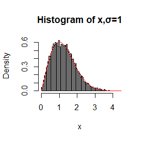

```r
Delta <- 1       ##设置参数
n <- 10000      ##选择生成随机样本个数
u <- runif(n)     ##生成均匀分布u
x <- sqrt(-2*Delta^2*log(u))    ##生成Rayleigh(σ)分布的随机变量

##画出样本的密度直方图
hist(x, prob = TRUE, breaks = 100, main = "Histogram of x,σ=1")

##画出Rayleigh(σ)分布的密度曲线进行比较
y <- seq(0, 1000, .1)
lines(y, y*exp(-y^2/(2*Delta^2))/Delta^2, col='red')
```

由直方图可以看出样本众数接近σ=1。

选择不同σ来模拟

当σ=2,3,4,5,6,7,8,9时，

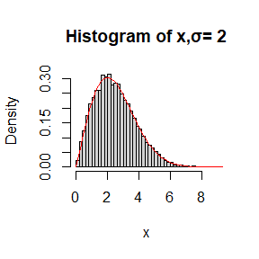

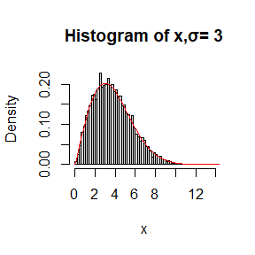

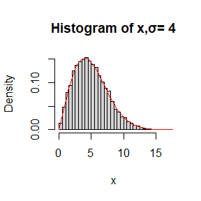

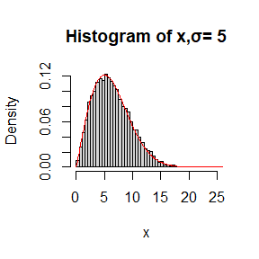

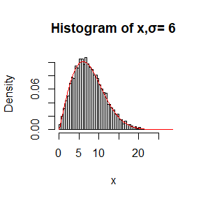

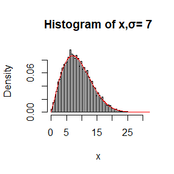

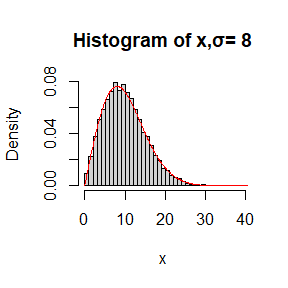

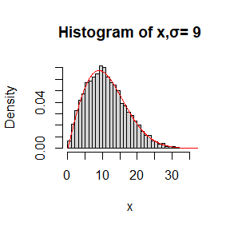

```r
Delta_values <- seq(2, 9, 1)  ##先生成σ的所有取值

##再逐个赋值循环生成
for(Delta in Delta_values){
  n <- 10000
  u <- runif(n)
  x <- sqrt(-2*Delta^2*log(u))
  hist(x, prob = TRUE, breaks = 50, main = paste("Histogram of x,σ=",Delta))
  y <- seq(0, 1000, .1)
  lines(y, y*exp(-y^2/(2*Delta^2))/Delta^2,col='red')
}
```

可见样本众数接近σ。

当σ=0.1,0.2,0.3,0.4,0.5,0.6,0.7,0.8,0.9时，

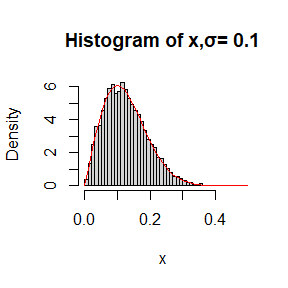

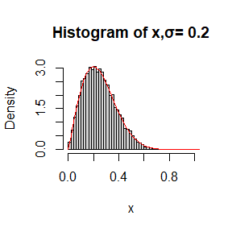

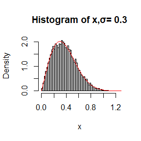

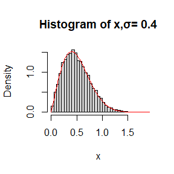

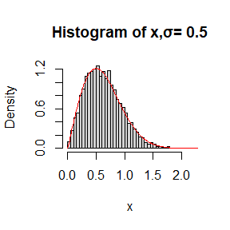

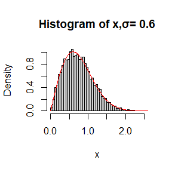

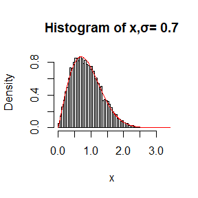

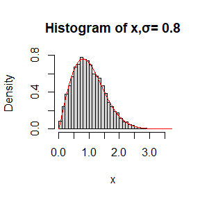

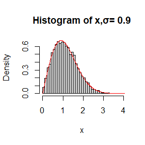

```r
Delta_values <- seq(.1, .9, .1)  ##先生成σ的所有取值

##再逐个赋值循环生成
for(Delta in Delta_values){
  n <- 10000
  u <- runif(n)
  x <- sqrt(-2*Delta^2*log(u))
  hist(x, prob = TRUE, breaks = 50, main = paste("Histogram of x,σ=",Delta))
  y <- seq(0, 1000, .01)
  lines(y, y*exp(-y^2/(2*Delta^2))/Delta^2,col='red')
}
```

可见样本众数接近σ。

当σ=10,15,20,25,30,35,40,45,50时，

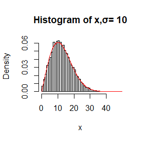

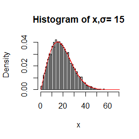

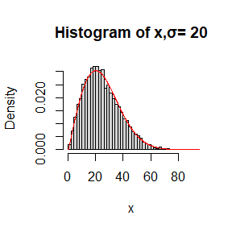

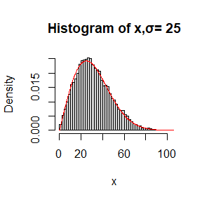

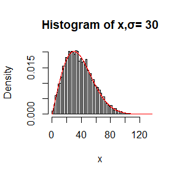

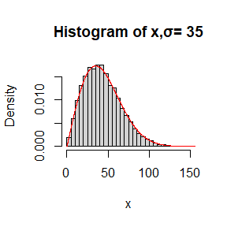

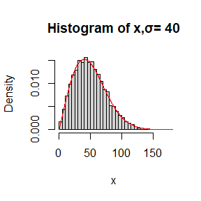

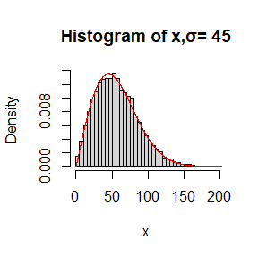

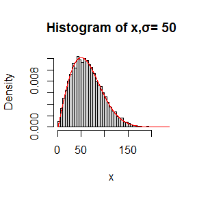

```r
Delta_values <- seq(10, 50, 5)  ##先生成σ的所有取值

##再逐个赋值循环生成
for(Delta in Delta_values){
  n <- 10000
  u <- runif(n)
  x <- sqrt(-2*Delta^2*log(u))
  hist(x, prob = TRUE, breaks = 50, main = paste("Histogram of x,σ=",Delta))
  y <- seq(0, 1000, .1)
  lines(y, y*exp(-y^2/(2*Delta^2))/Delta^2,col='red')
}
```

可见样本众数接近σ。

综上，可以认为生成样本的众数接近理论众数σ。

## 第二题（3.11）

先进行1000次“0-1”抽样，“0”对应$N(0,1)$分布，“1”对应$N(3,1)$分布，逐个生成即可

算法代码（$p1$=0.5)

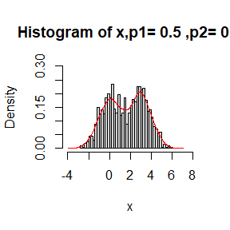

```r
n <- 1000  ##设置模拟次数
##设置参数
p1 <- 0.5
p2 <- 1-p1
##“0-1”抽样
k <- sample(0:1, size=n, replace=TRUE, prob = c(p1,p2))
mean <- 3*k  ##将“0”，“1”与相应分布对应
x <- rnorm(n, mean = mean, sd=1)  ##生成混合分布
##画出密度直方图
hist(x, prob = TRUE, breaks = 50, xlim = c(-4,8), ylim = c(0,.3), main = paste("Histogram of x,p1=",p1,",p2=",p2))
lines(density(x), col='red')  ##叠加密度曲线
```

可见当p1=0.5时有明显双峰

当p1=0.1，0.2，0.3，0.4时

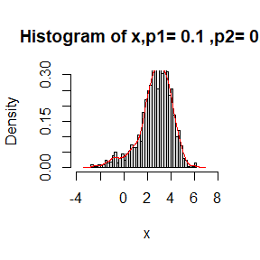

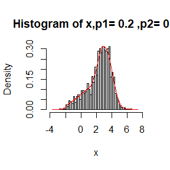

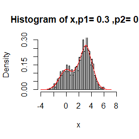

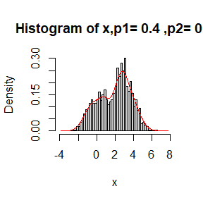

```r
##先给出p1的所有取值
p1_values <- seq(0.1, 0.4, by = 0.1)
##对于每个p1生成随机样本并绘图
for (p1 in p1_values) {
  p2 <- 1-p1
##“0-1”抽样
k <- sample(0:1, size=n, replace=TRUE, prob = c(p1,p2))
mean<-3*k  ##将“0”，“1”与相应分布对应
x <- rnorm(n, mean = mean, sd=1)  ##生成混合分布
##画出密度直方图
hist(x, prob = TRUE, breaks = 50, xlim = c(-4,8), ylim = c(0,.3), main = paste("Histogram of x,p1=",p1,",p2=",p2))
lines(density(x), col='red')  ##叠加密度曲线
}
```

当p1=0.6，0.7，0.8，0.9时

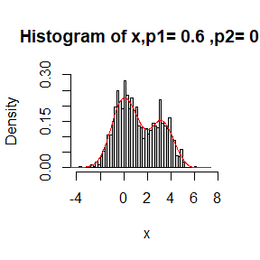

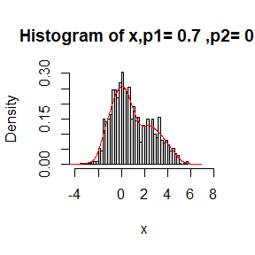

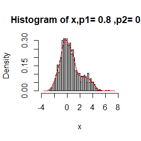

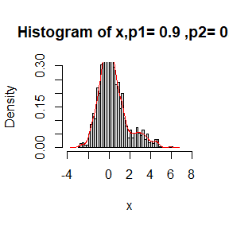

```r
##先给出p1的所有取值
p1_values <- seq(0.6, 0.9, by = 0.1)
##对于每个p1生成随机样本并绘图
for (p1 in p1_values) {
  p2 <- 1-p1
##“0-1”抽样
k <- sample(0:1, size=n, replace=TRUE, prob = c(p1,p2))
mean<-3*k  ##将“0”，“1”与相应分布对应
x <- rnorm(n, mean = mean, sd=1)  ##生成混合分布
##画出密度直方图
hist(x, prob = TRUE, breaks = 50, xlim = c(-4,8), ylim = c(0,.3), main = paste("Histogram of x,p1=",p1,",p2=",p2))
lines(density(x), col='red')  ##叠加密度曲线
}
```

当p1=0.25，0.75时

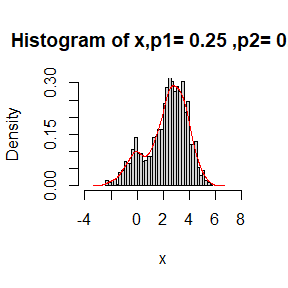

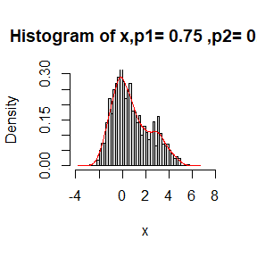

```r
##先给出p1的所有取值
p1_values <- c(.25,.75)
##对于每个p1生成随机样本并绘图
for (p1 in p1_values) {
  p2 <- 1-p1
##“0-1”抽样
k <- sample(0:1, size=n, replace=TRUE, prob = c(p1,p2))
mean<-3*k  ##将“0”，“1”与相应分布对应
x <- rnorm(n, mean = mean, sd=1)  ##生成混合分布
##画出密度直方图
hist(x, prob = TRUE, breaks = 50, xlim = c(-4,8), ylim = c(0,.3), main = paste("Histogram of x,p1=",p1,",p2=",p2))
lines(density(x), col='red')  ##叠加密度曲线
}
```

综上，可以推测当p1越接近0.5，双峰越明显，p1离0.5越远，双峰越不明显。

## 第三题（3.20）

先模拟出t=10条件下的Poisson过程{$Nt,t\geq0$}，（相当于生成参数为λt的Poisson分布，λ为事件的平均发生率）再对每个生成的$Nt$生成相应数量的Gamma分布{$Yn$}样本,并求和，即可得到{$Xt,t\geq0$}

算法（以λ=α=β=1为例）

```r
n <- 1000  ##设置模拟次数
##设置参数
lambda <- 1  ##设置Poisson过程的参数λ
shape <- 1  ##设置Gamma分布的参数α
rate <- 1  ##设置Gamma分布的参数β
t <- 10  ##设置Poisson过程的时间

X <- integer(n)  ##设置一个初始化向量

##模拟混合Poisson(λ)–Gamma过程
for(i in 1:n){
  N <- rpois(1, lambda*t)  ##先生成泊松过程{Nt}
  Y <- rgamma(N,shape,rate)  ##再生成相应的Gamma分布{Yi}
  X[i] <- sum(Y)  ##生成随机过程{Xt}
}
##求出X10的均值和方差
mean <- mean(X)
sd <- var(X)

##再计算其理论均值和方差
mean_the <- lambda*t*(shape/rate)
sd_the <- lambda*t*(shape/(rate*rate)+(shape/rate)^2)

##输出数据进行比较
cat(" X10的均值是：", mean, "\n","X10的方差是：", sd, "\n", "X10的理论均值是：", mean_the, "\n","X10的理论方差是：", sd_the, "\n")
```

```
##  X10的均值是： 9.893922
##  X10的方差是： 20.79293
##  X10的理论均值是： 10
##  X10的理论方差是： 20
```

可以看出生成的随机样本的均值与方差与理论数据基本吻合

λ=2, α=2, β=1

```r
n <- 1000  ##设置模拟次数
##设置参数
lambda <- 2  ##设置Poisson过程的参数λ
shape <- 2  ##设置Gamma分布的参数α
rate <- 1  ##设置Gamma分布的参数β
t <- 10  ##设置Poisson过程的时间

X <- integer(n)  ##设置一个初始化向量

##模拟混合Poisson(λ)–Gamma过程
for(i in 1:n){
  N <- rpois(1, lambda*t)  ##先生成泊松过程{Nt}
  Y <- rgamma(N,shape,rate)  ##再生成相应的Gamma分布{Yi}
  X[i] <- sum(Y)  ##生成随机过程{Xt}
}
##求出X10的均值和方差
mean <- mean(X)
sd <- var(X)

##再计算其理论均值和方差
mean_the <- lambda*t*(shape/rate)
sd_the <- lambda*t*(shape/(rate*rate)+(shape/rate)^2)

##输出数据进行比较
cat(" X10的均值是：", mean, "\n","X10的方差是：", sd, "\n", "X10的理论均值是：", mean_the, "\n","X10的理论方差是：", sd_the, "\n")
```

```
##  X10的均值是： 39.87797
##  X10的方差是： 120.5757
##  X10的理论均值是： 40
##  X10的理论方差是： 120
```

λ=4, α=2, β=2

```r
n <- 1000  ##设置模拟次数
##设置参数
lambda <- 4  ##设置Poisson过程的参数λ
shape <- 2  ##设置Gamma分布的参数α
rate <- 2  ##设置Gamma分布的参数β
t <- 10  ##设置Poisson过程的时间

X <- integer(n)  ##设置一个初始化向量

##模拟混合Poisson(λ)–Gamma过程
for(i in 1:n){
  N <- rpois(1, lambda*t)  ##先生成泊松过程{Nt}
  Y <- rgamma(N,shape,rate)  ##再生成相应的Gamma分布{Yi}
  X[i] <- sum(Y)  ##生成随机过程{Xt}
}
##求出X10的均值和方差
mean <- mean(X)
sd <- var(X)

##再计算其理论均值和方差
mean_the <- lambda*t*(shape/rate)
sd_the <- lambda*t*(shape/(rate*rate)+(shape/rate)^2)

##输出数据进行比较
cat(" X10的均值是：", mean, "\n","X10的方差是：", sd, "\n", "X10的理论均值是：", mean_the, "\n","X10的理论方差是：", sd_the, "\n")
```

```
##  X10的均值是： 40.28467
##  X10的方差是： 57.22368
##  X10的理论均值是： 40
##  X10的理论方差是： 60
```

λ=5, α=3, β=2

```r
n <- 1000  ##设置模拟次数
##设置参数
lambda <- 5  ##设置Poisson过程的参数λ
shape <- 3  ##设置Gamma分布的参数α
rate <- 2  ##设置Gamma分布的参数β
t <- 10  ##设置Poisson过程的时间

X <- integer(n)  ##设置一个初始化向量

##模拟混合Poisson(λ)–Gamma过程
for(i in 1:n){
  N <- rpois(1, lambda*t)  ##先生成泊松过程{Nt}
  Y <- rgamma(N,shape,rate)  ##再生成相应的Gamma分布{Yi}
  X[i] <- sum(Y)  ##生成随机过程{Xt}
}
##求出X10的均值和方差
mean <- mean(X)
sd <- var(X)

##再计算其理论均值和方差
mean_the <- lambda*t*(shape/rate)
sd_the <- lambda*t*(shape/(rate*rate)+(shape/rate)^2)

##输出数据进行比较
cat(" X10的均值是：", mean, "\n","X10的方差是：", sd, "\n", "X10的理论均值是：", mean_the, "\n","X10的理论方差是：", sd_the, "\n")
```

```
##  X10的均值是： 75.11608
##  X10的方差是： 149.9173
##  X10的理论均值是： 75
##  X10的理论方差是： 150
```

综上，可以看出生成的随机样本的均值与方差与理论数据基本吻合

# 第三次作业

## 第一题 （5.4）

Beta（3，3）的概率密度函数（PDF）为$f(x)=30x^2(1-x)^2$ 为了实现贝塔分布Beta(3,3)的累积分布函数（CDF）的蒙特卡罗估计，先生成m个$[0,x]$上的均匀随机分布样本$t_i$，再用其（PDF）得到$g_i$。由蒙特卡罗估计，利用$\frac{\int_0^x f(t) \, dt}{x}=\frac{\sum_{i=1}^{m}g_i}{m}$来估计(CDF)($\int_0^x f(t) \, dt$)

```r
## 先确定x的取值
x <- seq(.1, .9, .1)

## 对每一个x用上述方法计算对应CDF的估计值
cdf <- numeric(9)
for (i in 1:9){
  m <- 100000
  t <- runif(m, min = 0, max = x[i])
  g <- t*t*(1-t)*(1-t)*30
  cdf[i] <- x[i]*sum(g)/m
}

## 输出估计值
print(cdf)
```

```
## [1] 0.008496333 0.057787446 0.162577962 0.318533509 0.500660818 0.681461341
## [7] 0.835704457 0.942017103 0.990489929
```

```r
## 与 pbeta 函数的输出值进行比较
Phi <- pbeta(x, 3, 3)
print(round(rbind(x, cdf, Phi), 3))
```

```
##      [,1]  [,2]  [,3]  [,4]  [,5]  [,6]  [,7]  [,8]  [,9]
## x   0.100 0.200 0.300 0.400 0.500 0.600 0.700 0.800 0.900
## cdf 0.008 0.058 0.163 0.319 0.501 0.681 0.836 0.942 0.990
## Phi 0.009 0.058 0.163 0.317 0.500 0.683 0.837 0.942 0.991
```

可以看出两者相差不大

## 第二题 （5.9）

为了使用对偶变量法给出额能生成服从瑞利分布（Rayleigh(σ)分布）的样本的函数，先用逆变换法生成服从Rayleigh(σ)分布的随机变量。 由其概率密度函数$f(x)=\frac{x}{σ^2}e^{-\frac{x^2}{2σ^2}},x\geq0,σ>0$,可以得到其概率分布函数$F(x)=1-e^{-x^2/(2σ^2)},x\geq0,σ>0$,从而得到$F^{-1}(u)=σ*\sqrt{-2*log(1-u)}$。而$u$与$1-u$均服从$U（0，1）$，故由对偶变量法，生成一组均匀随机变量$u$后，可先用$x=F^{-1}(u)=σ*\sqrt{-2*log(1-u)}$来生成随机样本$X=X_1$，再用$x=F^{-1}(u)=σ*\sqrt{-2*log(u)}$来生成样本$X'$,同时用生成$X_1$的方法生成一组独立的随机变量$X_2$。最后比较$\frac{X_1+X_2}{2}$与$\frac{X+X'}{2}$的均值与方差。（本例中取σ=1）

```r
## 给出生成x,x1,x',x2的函数,
MC.Phi <- function(Delta, n, antithetic = FALSE) {
  u <- runif(n)
  if (antithetic) v <- 1 - u  ## 当anti=TRUE时生成(x+x')/2
  else v <- runif(n)  ## 当anti=FALSE时生成(x1+x2)/2
  x <- Delta*sqrt(-2*log(1-u))
  y <- Delta*sqrt(-2*log(1-v))
  x <- (x+y)/2
}

## 取参数σ=1，n=1000
Delta = 1
n = 1000

## 设置种子
set.seed(123)

## 分别生成(x1+x2)/2与(x+x')/2
MC1 = MC.Phi(Delta, n, anti=FALSE)
MC2 = MC.Phi(Delta, n, anti=TRUE)

## 计算并输出两者均值
print(mean(MC1))
```

```
## [1] 1.247115
```

```r
print(mean(MC2))
```

```
## [1] 1.25416
```

```r
## 计算并输出两者标准差
print(sd(MC1))
```

```
## [1] 0.4509472
```

```r
print(sd(MC2))
```

```
## [1] 0.1038592
```

```r
## 计算并输出方差缩减
print((var(MC1)-var(MC2))/var(MC1))
```

```
## [1] 0.9469557
```

可以看出，在σ=1时，相比于$\frac{X_1+X_2}{2}$，$\frac{X+X'}{2}$的平均值几乎不变，但方差缩减将近95%

## 第三题 （5.13）

对于$g(x)=\frac{x^2}{\sqrt{2\pi}} e^{-\frac{x^2}{2}},x>1$, 用重要抽样法估计$\int_1^{+\infty} \frac{x^2}{\sqrt{2\pi}} e^{-\frac{x^2}{2}} \, dx$，分别选取支撑集在$(0,+\infty)$上且接近函数g(x)的重要函数$f_1=e^{-x}$,$f_2=\frac{2}{\pi(1+x^2)}$,$f_3=xe^{-x}$,$f_4=\frac{1}{\sqrt{2\pi}}e^{-\frac{(x-2)^2}{2}}$。(f1是参数为1的指数分布,f2可以用逆变换法生成,f3是参数为（2，1）的伽马分布,f4是参数为（2，1）的正态分布。)

```r
## 写出题中所用函数g,f1,f2,f3,f4
g <- function(x){
  x^2*exp(-x^2/2)/ sqrt(2 * pi)*(x>1)
}
f1 <- function(x){
  exp(-x)
}
f2 <- function(x){
  (1+x^2)^(-1)*2/pi
}
f3 <- function(x){
  x*exp(-x)
}
f4 <- function(x){
  1 / sqrt(2 * pi)*exp(-1/2*(x-2)^2)
}

## 设置生成样本大小
m <- 10000

## 生成两个4维零向量
theta.hat <- se <- numeric(4)

## 生成f1并计算其均值和标准差
x <- rexp(m,1)
fg <- g(x)/f1(x)
theta.hat[1] <- mean(fg)
se[1] <- sd(fg)

## 生成f2并计算其均值和标准差
u <- runif(m)
x <- tan(pi*u/2)
fg <- g(x)/f2(x)
theta.hat[2] <- mean(fg)
se[2] <- sd(fg)

## 生成f3并计算其均值和标准差
x <- rgamma(x, shape = 2, rate = 1)
fg <- g(x)/f3(x)
theta.hat[3] <- mean(fg)
se[3] <- sd(fg)

## 生成f4并计算其均值和标准差
x <- rnorm(x, mean = 2, sd = 1)
fg <- g(x)/f4(x)
theta.hat[4] <- mean(fg)
se[4] <- sd(fg)

## 显示模拟结果
rbind(theta.hat,se)
```

```
##                [,1]      [,2]      [,3]      [,4]
## theta.hat 0.4016253 0.3950521 0.4046431 0.3959383
## se        0.5857676 0.6136091 0.3670986 0.3223572
```

综上，四个函数产生的均值相当，而$f_4=\frac{1}{\sqrt{2\pi}}e^{-\frac{(x-2)^2}{2}}$产生的方差最小。

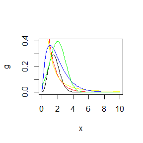

```r
## 绘制g,f1,f2,f3,f4的函数图像
x <- seq(0, 10, .1)
g <- x^2*exp(-x^2/2)/ sqrt(2 * pi)
f1 <- exp(-x)
f2 <- (1+x^2)^(-1)*2/pi
f3 <- x*exp(-x)
f4 <- 1 / sqrt(2 * pi)*exp(-1/2*(x-2)^2)

plot(x, g, type = "l", ylim=c(0, .4))
lines(x, f1 ,col = "red")
lines(x, f2 ,col = "yellow")
lines(x, f3 ,col = "blue")
lines(x, f4 ,col = "green")
```

图中f4（绿线）更为接近g（黑线），产生方差更小。

## 第四题 （快速排序）

通过对$n=10^4,2\times10^4,4\times10^4,6\times10^4,8\times10^4$分别各自进行100次快速排序算法，并计算其平均时间$a_n$,并用$t_n=nlog(n)$作为自变量，对$a_n$进行回归分析，最终绘制散点图和回归线，展示$a_n$与$t_n=nlog(n)$之间的关系。

```r
## 给出快速排序的函数
quick_sort<-function(x){
  num<-length(x)
  if(num==0||num==1){return(x)
  }else{
    a<-x[1]
    y<-x[-1]
    lower<-y[y<a]
    upper<-y[y>=a]
    return(c(quick_sort(lower),a,quick_sort(upper)))}
}

## 生成一个100维的空向量
times <- numeric(100)

## 给出计算100次模拟实验的平均时间的函数
computeAverageTime <- function(n) {
  for (i in 1:100){
    test<-sample(1:n)
    times[i]<-system.time(quick_sort(test))[1]
  }
  return(mean(times))
}

## 设置种子
set.seed(123)

## 对不同数据进行模拟实验
n <- c(10^4, 2*10^4, 4*10^4, 6*10^4, 8*10^4)
dim(n) <- length(n)
an <- apply(n, MARGIN=1, FUN = computeAverageTime)

## 输出an
print(an)
```

```
## [1] 0.0162 0.0322 0.0691 0.1072 0.1400
```

```r
## 进行回归分析
tn <- n*log(n)
model <- lm(an ~ tn)
summary(model)
```

```
##
## Call:
## lm(formula = an ~ tn)
##
## Residuals:
##          1          2          3          4          5
## -0.0005751 -0.0009542  0.0010450  0.0026266 -0.0021422
##
## Coefficients:
##              Estimate Std. Error t value Pr(>|t|)
## (Intercept) 2.539e-03  1.757e-03   1.445    0.244
## tn          1.546e-07  3.230e-09  47.855 2.01e-05 ***
## ---
## Signif. codes:  0 '***' 0.001 '**' 0.01 '*' 0.05 '.' 0.1 ' ' 1
##
## Residual standard error: 0.002146 on 3 degrees of freedom
## Multiple R-squared:  0.9987, Adjusted R-squared:  0.9983
## F-statistic:  2290 on 1 and 3 DF,  p-value: 2.009e-05
```

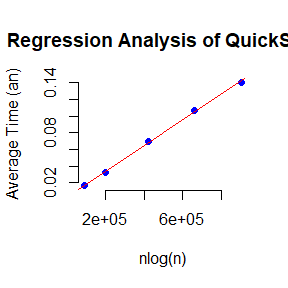

```r
## 绘制散点图和回归线，展示an与tn之间的关系
plot(tn, an, xlab = "nlog(n)", ylab = "Average Time (an)",
     main = "Regression Analysis of QuickSort",
     pch = 19, frame = FALSE, col = "blue")
abline(model, col = "red")
```

可见，$a_n$与$t_n=nlog(n)$基本满足线性关系，故可以认为快速排序法的平均时间复杂度是$O(nlogn)$。

# 第四次作业

## 第一题（6.6）

进行多次蒙特卡罗实验生成正态分布样本，使用e1071包中的skewness函数来计算样本偏度，用quantile函数来估计其分位数。并与大样本近似$N(0,6/n)$进行比较。同时计算（2.14）($\operatorname{Var}\left(\hat{x}_{q}\right) = \frac{q(1-q)}{n f\left(x_{q}\right)^{2}}$)中的标准误差。

```r
## 加载e1071包并设置样本大小，模拟试验次数，以及分位数
library(e1071)
n <-1000
m <-10000
q <- c(0.025, 0.05, 0.95, 0.975)

## 依次生成m次样本大小为n的正态分布并计算其偏度
skewness_samples <- replicate(m, {
  samples <- rnorm(n)
  skewness(samples)
}
)

## 估计样本偏度的0.025, 0.05, 0.95, 0.975分位数
quantiles <- quantile(skewness_samples, probs = q)
print(quantiles)
```

```
##       2.5%         5%        95%      97.5%
## -0.1548490 -0.1284037  0.1303155  0.1555197
```

```r
## 计算并输出（2.14）中的标准误差
var_quantiles <- q*(1-q)/(n*dnorm(quantiles)^2)
print(var_quantiles)
```

```
##         2.5%           5%          95%        97.5%
## 0.0001568693 0.0003034128 0.0003035629 0.0001569020
```

```r
## 生成大样本近似的0.025, 0.05, 0.95, 0.975分位数
z_scores <- qnorm(q, mean = 0, sd = sqrt(6/n))
print(z_scores)
```

```
## [1] -0.1518182 -0.1274098  0.1274098  0.1518182
```

```r
##进行比较
rbind(quantiles, z_scores, var_quantiles)
```

```
##                        2.5%            5%          95%       97.5%
## quantiles     -0.1548489907 -0.1284036535 0.1303154537 0.155519700
## z_scores      -0.1518181574 -0.1274098141 0.1274098141 0.151818157
## var_quantiles  0.0001568693  0.0003034128 0.0003035629 0.000156902
```

经过比较，估计样本偏度的0.025, 0.05, 0.95, 0.975分位数与大样本近似的0.025, 0.05, 0.95, 0.975分位数极为接近。

## 第二题 （6.B）

对一个二元正态抽样分布用”cor.test”进行Pearson、Spearman 和 Kendall 相关系数的检验，并比较三者功效。 再找到一个选择的例子使至少有一个非参数检验的经验功效要比相关性检验的功效高，仍用”cor.test”进行Pearson、Spearman和Kendall相关系数的检验，计算三者功效。

```r
## 加载MASS安装包并给出二元正态分布数据
library(MASS)
set.seed(123) ## 设置种子
n <- 100  ## 样本大小
mu <- c(0, 0)  ## 均值向量
Sigma <- matrix(c(1, 0.5, 0.5, 1), 2, 2)  ## 协方差矩阵 (相关系数为0.5)

## 生成二元正态分布样本
data <- mvrnorm(n, mu = mu, Sigma = Sigma)
x <- data[, 1]
y <- data[, 2]

## Pearson相关系数检验
pearson_test <- cor.test(x, y, method = "pearson")
print(pearson_test)
```

```
##
##  Pearson's product-moment correlation
##
## data:  x and y
## t = 5.0718, df = 98, p-value = 1.866e-06
## alternative hypothesis: true correlation is not equal to 0
## 95 percent confidence interval:
##  0.2850878 0.5987650
## sample estimates:
##      cor
## 0.455973
```

```r
## Spearman相关系数检验
spearman_test <- cor.test(x, y, method = "spearman")
print(spearman_test)
```

```
##
##  Spearman's rank correlation rho
##
## data:  x and y
## S = 94296, p-value = 7.933e-06
## alternative hypothesis: true rho is not equal to 0
## sample estimates:
##       rho
## 0.4341674
```

```r
## Kendall相关系数检验
kendall_test <- cor.test(x, y, method = "kendall")
print(kendall_test)
```

```
##
##  Kendall's rank correlation tau
##
## data:  x and y
## z = 4.497, p-value = 6.893e-06
## alternative hypothesis: true tau is not equal to 0
## sample estimates:
##       tau
## 0.3050505
```

```r
## 通过蒙特卡罗模拟来进行功效比较
n_simulations <- 10000
p_values_pearson <- numeric(n_simulations)
p_values_spearman <- numeric(n_simulations)
p_values_kendall <- numeric(n_simulations)

for (i in 1:n_simulations) {
  sample_data <- mvrnorm(n, mu = mu, Sigma = Sigma)
  x_sample <- sample_data[, 1]
  y_sample <- sample_data[, 2]

  p_values_pearson[i] <- cor.test(x_sample, y_sample, method = "pearson")$p.value
  p_values_spearman[i] <- cor.test(x_sample, y_sample, method = "spearman")$p.value
  p_values_kendall[i] <- cor.test(x_sample, y_sample, method = "kendall")$p.value
}

## 计算功效 (假设显著性水平 alpha = 0.05)
alpha <- 0.05
power_pearson <- mean(p_values_pearson < alpha)
power_spearman <- mean(p_values_spearman < alpha)
power_kendall <- mean(p_values_kendall < alpha)

cat("Pearson 的功效：", power_pearson, "\n")
```

```
## Pearson 的功效： 0.9998
```

```r
cat("Spearman 的功效：", power_spearman, "\n")
```

```
## Spearman 的功效： 0.9994
```

```r
cat("Kendall 的功效：", power_kendall, "\n")
```

```
## Kendall 的功效： 0.9994
```

可见，二元正态抽样分布下，相关性检验比非参数检验功效更高。

再选择一组非正态分布的x与y

```r
## 设置样本大小
n <- 100

## 设置种子
set.seed(1234)

## 生成非正态分布的x和y
x <- runif(n)
y <- log(x)+rnorm(n,sd=1)^3

## Pearson相关系数检验
pearson_test <- cor.test(x, y, method = "pearson")
print(pearson_test)
```

```
##
##  Pearson's product-moment correlation
##
## data:  x and y
## t = 3.3113, df = 98, p-value = 0.001301
## alternative hypothesis: true correlation is not equal to 0
## 95 percent confidence interval:
##  0.1288232 0.4835071
## sample estimates:
##       cor
## 0.3172147
```

```r
## Spearman相关系数检验
spearman_test <- cor.test(x, y, method = "spearman")
print(spearman_test)
```

```
##
##  Spearman's rank correlation rho
##
## data:  x and y
## S = 72242, p-value = 1.061e-09
## alternative hypothesis: true rho is not equal to 0
## sample estimates:
##       rho
## 0.5665047
```

```r
## Kendall相关系数检验
kendall_test <- cor.test(x, y, method = "kendall")
print(kendall_test)
```

```
##
##  Kendall's rank correlation tau
##
## data:  x and y
## z = 6.7127, p-value = 1.911e-11
## alternative hypothesis: true tau is not equal to 0
## sample estimates:
##       tau
## 0.4553535
```

```r
## 通过蒙特卡罗模拟来进行功效比较
n_simulations <- 1000
p_values_pearson <- numeric(n_simulations)
p_values_spearman <- numeric(n_simulations)
p_values_kendall <- numeric(n_simulations)

for (i in 1:n_simulations) {
  x_sim <- runif(n)
  y_sim <- log(x_sim)+rnorm(n,sd=1)^3

  p_values_pearson[i] <- cor.test(x_sim, y_sim, method = "pearson")$p.value
  p_values_spearman[i] <- cor.test(x_sim, y_sim, method = "spearman")$p.value
  p_values_kendall[i] <- cor.test(x_sim, y_sim, method = "kendall")$p.value
}

## 计算功效 (假设显著性水平 alpha = 0.05)
alpha <- 0.05
power_pearson <- mean(p_values_pearson < alpha)
power_spearman <- mean(p_values_spearman < alpha)
power_kendall <- mean(p_values_kendall < alpha)

cat("Pearson 的功效：", power_pearson, "\n")
```

```
## Pearson 的功效： 0.619
```

```r
cat("Spearman 的功效：", power_spearman, "\n")
```

```
## Spearman 的功效： 1
```

```r
cat("Kendall 的功效：", power_kendall, "\n")
```

```
## Kendall 的功效： 1
```

可见，存在非参数检验的功效比相关性检验的功效要高

## 第三题 （比较两种方法的功效是否存在显示差异,当显著性水平$\alpha$=0.05时）

$H_0$:两种方法的功效没有显著差异,可以认为$p1=p2$. v.s. $H_1$:两种方法的功效存在显著差异，$p1\neq p2$ 因为两种方法相互独立，且样本数据较大，适合近似正态分布的假设，故可以使用 两样本Z检验来比较两者的比例差异。 先使用标准二项分布公式计算总体的标准误差，再根据两种方法的功效差异除以标准误差，得出Z值，并使用pnorm函数计算双侧p值，判断差异是否显著。最后，在显著性水平$\alpha$=0.05下，判断是否拒绝$H_0$。(当$p < \alpha$时，拒绝$H_0$；当$p \geq \alpha$时，接受$H_0$)

```r
## 分别输入两种方法的功效,并设置模拟实验次数
p1 <- 0.651
p2 <- 0.676
n <- 10000

## 计算总体标准误差，Z 值以及双侧检验的 p 值
se <- sqrt((p1 * (1 - p1) / n) + (p2 * (1 - p2) / n))
z <- (p1 - p2) / se
p <- 2 * pnorm(-abs(z))

## 输出 Z 值和 p 值
cat("Z 值:", z, "\n")
```

```
## Z 值: -3.742519
```

```r
cat("p 值:", p, "\n")
```

```
## p 值: 0.0001821846
```

```r
## 在显著性水平alpha=0.05时，判断是否拒绝零假设
alpha <- 0.05
if (p < alpha) {
  cat("在显著性水平", alpha, "下，拒绝零假设，两种方法的功效有显著差异。\n")
} else {
  cat("在显著性水平", alpha, "下，不能拒绝零假设，两种方法的功效没有显著差异。\n")
}
```

```
## 在显著性水平 0.05 下，拒绝零假设，两种方法的功效有显著差异。
```

# 第五次作业

## 第一题（7.4）

因为故障之间的时间服从指数模型Exp(λ)。对于指数分布，λ的极大似然估计（MLE）为平均故障时间的倒数，即
$$\frac{1}{\lambda}$$
=“平均故障时间”。故我们使用故障之间的时间的平均数来计算λ的最大似然估计（MLE）。

```r
# 加载所需包
library(boot)

# 使用 boot 包中的aircondit数据集
data("aircondit")

# 将aircondit数据集转化为一个向量
failure_times <- aircondit$hours

# 使用故障之间的时间的平均数来计算λ的最大似然估计（MLE）
lambda_mle <- 1 / mean(failure_times)
cat("λ的最大似然估计:", lambda_mle, "\n")
```

```
## λ的最大似然估计: 0.00925212
```

```r
# 基于自助法定义用于boot的统计量函数（对原数据进行重抽样并用重抽样结果来计算λ的MLE）
lambda_boot_fn <- function(data, indices) {
  sample_data <- data[indices]
  return(1 / mean(sample_data))
}

# 使用boot进行自助法估计
boot_results <- boot(data = failure_times, statistic = lambda_boot_fn, R = 2000)

# 显示自助法估计结果
boot_results
```

```
##
## ORDINARY NONPARAMETRIC BOOTSTRAP
##
##
## Call:
## boot(data = failure_times, statistic = lambda_boot_fn, R = 2000)
##
##
## Bootstrap Statistics :
##       original      bias    std. error
## t1* 0.00925212 0.001287425 0.004184443
```

```r
summary(boot_results)
```

```
##           Length Class  Mode
## t0           1   -none- numeric
## t         2000   -none- numeric
## R            1   -none- numeric
## data        12   -none- numeric
## seed       626   -none- numeric
## statistic    1   -none- function
## sim          1   -none- character
## call         4   -none- call
## stype        1   -none- character
## strata      12   -none- numeric
## weights     12   -none- numeric
```

```r
# 输出自助法结果
cat("自助法估计的均值:", mean(boot_results$t), "\n")
```

```
## 自助法估计的均值: 0.01053955
```

```r
cat("自助法估计的偏差:", mean(boot_results$t) - lambda_mle, "\n")
```

```
## 自助法估计的偏差: 0.001287425
```

```r
cat("自助法估计的标准误差:", sd(boot_results$t), "\n")
```

```
## 自助法估计的标准误差: 0.004184443
```

## 第二题（7.5）

```r
# 接上一题代码，用boot.ci函数计算自助法估计的四种95%置信区间
# 标准正态
ci_normal <- boot.ci(boot_results, type = "norm")
# 基本方法
ci_basic <- boot.ci(boot_results, type = "basic")
# 百分位数
ci_percentile <- boot.ci(boot_results, type = "perc")
# BCa方法
ci_bca <- boot.ci(boot_results, type = "bca")

#显示四种95%置信区间
# 标准正态
ci_normal
```

```
## BOOTSTRAP CONFIDENCE INTERVAL CALCULATIONS
## Based on 2000 bootstrap replicates
##
## CALL :
## boot.ci(boot.out = boot_results, type = "norm")
##
## Intervals :
## Level      Normal
## 95%   (-0.0002,  0.0162 )
## Calculations and Intervals on Original Scale
```

```r
# 基本方法
ci_basic
```

```
## BOOTSTRAP CONFIDENCE INTERVAL CALCULATIONS
## Based on 2000 bootstrap replicates
##
## CALL :
## boot.ci(boot.out = boot_results, type = "basic")
##
## Intervals :
## Level      Basic
## 95%   (-0.0027,  0.0131 )
## Calculations and Intervals on Original Scale
```

```r
# 百分位数
ci_percentile
```

```
## BOOTSTRAP CONFIDENCE INTERVAL CALCULATIONS
## Based on 2000 bootstrap replicates
##
## CALL :
## boot.ci(boot.out = boot_results, type = "perc")
##
## Intervals :
## Level     Percentile
## 95%   ( 0.0054,  0.0212 )
## Calculations and Intervals on Original Scale
```

```r
# BCa方法
ci_bca
```

```
## BOOTSTRAP CONFIDENCE INTERVAL CALCULATIONS
## Based on 2000 bootstrap replicates
##
## CALL :
## boot.ci(boot.out = boot_results, type = "bca")
##
## Intervals :
## Level       BCa
## 95%   ( 0.0046,  0.0178 )
## Calculations and Intervals on Original Scale
```

```r
# 输出各方法的置信区间进行比较
cat("标准正态法下的95%置信区间:", ci_normal$normal[2:3], "\n")
```

```
## 标准正态法下的95%置信区间: -0.0002366619 0.01616605
```

```r
cat("基本法下的95%置信区间:", ci_basic$basic[4:5], "\n")
```

```
## 基本法下的95%置信区间: -0.00269623 0.01308663
```

```r
cat("百分位数法下的95%置信区间:", ci_percentile$percent[4:5], "\n")
```

```
## 百分位数法下的95%置信区间: 0.005417607 0.02120047
```

```r
cat("BCa方法下的95%置信区间:", ci_bca$bca[4:5], "\n")
```

```
## BCa方法下的95%置信区间: 0.004628785 0.01780647
```

对四种区间不同的解释：

（1）标准正态法：基于正态近似，假设统计量的分布是正态的，使用标准误差构建置信区间。由于标准正态法假设统计量是正态分布的，通常在样本量较大且数据对称时表现较好。

（2）基本法：计算原始统计量与自助法重抽样统计量的偏差，并在原始估计的基础上调整置信区间。由于基本法调整了统计量的偏差，可以修正某些分布不对称的情况。

（3）百分位数法：直接使用自助法重抽样统计量的分布的百分位数来构建置信区间。百分位数法更加依赖于重抽样的分布，因此不做任何对称性或正态性的假设。

（4）BCa 方法：Bias-Corrected and Accelerated，是一种调整偏差和加速的自助法置信区间。BCa 方法进一步校正了偏差，并考虑到数据的不对称性，因此在小样本和非对称分布下，BCa 通常表现得更为准确。

综上，四种区间的不同主要来自于各种方法对偏差和分布形态的不同假设和校正方式。

## 第三题（P值校正与模拟分析）

用均匀分布生成假设零成立下的950个P值，再用参数为0.1和1的Beta分布生成假设零不成立下的P值。再分别获取Bonferroni校正后的P值和B-H校正后的P值，计算在显著性水平
$$\alpha=0.1$$
下的FWER，FDR和TPR.最后再对获得的所有FWER，FDR和TPR取平均数作为最终结果。

```r
# 参数设定
# 总假设数量
N <- 1000
# 模拟实验次数
m <- 10000
# 显著性水平
alpha <- 0.1
# 零假设成立的数量
num_null <- 950
# 零假设不成立的数量
num_alt <- 50

# 初始化用于存储结果的向量
fwer_bonf <- fdr_bonf <- tpr_bonf <- numeric(m)
fwer_bh <- fdr_bh <- tpr_bh <- numeric(m)

# 开始m次重复模拟实验
for (i in 1:m) {
  # 生成P值
  # 零假设成立的P值，服从均匀分布
  p_null <- runif(num_null)
  # 零假设不成立的P值，服从Beta分布
  p_alt <- rbeta(num_alt, 0.1, 1)
  # 合并P值
  p_values <- c(p_null, p_alt)

  # Bonferroni校正
  p_bonf <- p.adjust(p_values, method = "bonferroni")
  # BH校正
  p_bh <- p.adjust(p_values, method = "BH")

  # 计算Bonferroni校正下的FWER, FDR, TPR
  rejections_bonf <- p_bonf < alpha
  fwer_bonf[i] <- sum(rejections_bonf[1:num_null] > 0) / N
  fdr_bonf[i] <- sum(rejections_bonf[1:num_null]) / max(sum(rejections_bonf), 1)
  tpr_bonf[i] <- sum(rejections_bonf[(num_null + 1):N]) / num_alt

  # 计算BH校正下的FWER, FDR, TPR
  rejections_bh <- p_bh < alpha
  fwer_bh[i] <- sum(rejections_bh[1:num_null] > 0) / N
  fdr_bh[i] <- sum(rejections_bh[1:num_null]) / max(sum(rejections_bh), 1)
  tpr_bh[i] <- sum(rejections_bh[(num_null + 1):N]) / num_alt
}

# 计算在m次模拟实验中获得的FWER, FDR, TPR的平均值，并生成3*2表格
result <- data.frame(
  Bonferroni = c(mean(fwer_bonf), mean(fdr_bonf), mean(tpr_bonf)),
  BH = c(mean(fwer_bh), mean(fdr_bh), mean(tpr_bh))
)
# 对表格的行命名
rownames(result) <- c("FWER", "FDR", "TPR")

# 输出结果
print(result)
```

```
##       Bonferroni         BH
## FWER 0.000096400 0.00307570
## FDR  0.004744776 0.09492217
## TPR  0.398918000 0.56231600
```

结果评价：

FWER：

```
Bonferroni校正严格控制了家族错误率（几乎为0），这是因为它通过非常严格的方式（对每个假设测试进行校正）减少了错误拒绝的概率。然而，这也导致它在控制假发现时可能会错过许多真正的显著性结果；

B-H校正的FWER略高，但仍然较低。这是因为B-H校正并不是针对FWER的，而是为了控制FDR。因此它允许有更多的假设被拒绝，从而能发现更多显著性结果。
```

FDR：

```
Bonferroni校正的FDR非常低，表示它几乎没有假发现。但这也是因为它非常严格地拒绝了很多显著性假设，导致TPR较低。

B-H校正专门用于控制FDR。它的假发现率虽然比Bonferroni校正高得多，但这是B-H校正的设计目标：在允许一定比例假发现的情况下，尽量多发现真正的显著性结果。
```

TPR：

```
Bonferroni校正的TPR较低，表明它在真正显著的假设中只有较低的可能被识别出来。这是Bonferroni校正的常见缺点，因为它过于严格，降低了拒绝零假设的机会，因此真正的显著性结果可能未能被发现。

B-H校正的TPR则相对较高，表明它比Bonferroni校正更能识别出真正的显著性结果。这是因为它允许更多的假设被拒绝，虽然这也带来较高的FDR，但在寻找真正显著的假设时更为有效。
```

总评：

```
Bonferroni校正非常严格，适用于对错误拒绝容忍度极低的情况，它的FWER和FDR都非常低，但以牺牲TPR为代价（即错过了很多真正的显著性结果）。

B-H校正则更宽松，允许更多假设被拒绝，适合在希望提高发现率时使用，尽管它的FDR较高，但仍然在可控范围内；它提高了TPR，能够识别出更多真正显著的结果，对于需要在发现显著结果和控制假发现之间平衡的场景，B-H校正通常更为合适。
```

# 第六次作业

## 第一题（7.8）

基于
$$\hat{\theta}=\frac{\hat{\lambda}_1}{\sum_{j=1}^{5}\hat{\lambda}_j}$$
，先根据数据集scor计算出基于所有数据的
$$\hat{\theta}$$
，再利用Jackknife方法，通过逐次移除每个样本，计算每个子样本的
$$\hat{\theta}$$
，最后使用Jackknife样本的结果计算整体估计的偏差和标准误即可。

```r
# 加载所需的R包
library(bootstrap)

# 获取数据集
data("scor")

# 计算数据集的协方差矩阵
cov_matrix <- cov(scor)

# 计算特征值
eigenvalues <- eigen(cov_matrix)$values

# 定义计算theta的函数
theta_hat <- function(eigen_vals) {
  return(eigen_vals[1] / sum(eigen_vals))
}

# 计算原始的theta_hat
theta_original <- theta_hat(eigenvalues)

# 进行Jackknife估计
# 根据scor数据集的行数给出样本数量
n <- nrow(scor)
# 定义一个用于储存数据的零向量
jackknife_theta <- numeric(n)

for (i in 1:n) {
  # 移除第 i 个样本
  jackknife_data <- scor[-i, ]

  # 计算新的协方差矩阵和特征值
  cov_matrix_jackknife <- cov(jackknife_data)
  eigenvalues_jackknife <- eigen(cov_matrix_jackknife)$values

  # 计算每个Jackknife样本的theta_hat
  jackknife_theta[i] <- theta_hat(eigenvalues_jackknife)
}

# 计算Jackknife平均
theta_jackknife_mean <- mean(jackknife_theta)

# 计算Jackknife偏差估计
bias_jackknife <- (n - 1) * (theta_jackknife_mean - theta_original)

# 计算Jackknife标准误
se_jackknife <- sqrt(((n - 1) / n) * sum((jackknife_theta - theta_jackknife_mean)^2))

# 输出结果
cat("原始的theta_hat:", theta_original, "\n")
```

```
## 原始的theta_hat: 0.619115
```

```r
cat("Jackknife的theta_hat:", theta_jackknife_mean, "\n")
```

```
## Jackknife的theta_hat: 0.6191273
```

```r
cat("Jackknife偏差估计:", bias_jackknife, "\n")
```

```
## Jackknife偏差估计: 0.001069139
```

```r
cat("Jackknife标准误估计:", se_jackknife, "\n")
```

```
## Jackknife标准误估计: 0.04955231
```

## 第二题（7.10）

参考例7.18，使用留一法交叉验证来来评估每个模型的预测误差并计算调整后的R^2来选择模型，将双对数模型替换为三次多项式模型。即交叉验证用于对线性模型、二次模型、三次多项式模型、指数模型四个模型进行比较。

```r
# 加载所需的包
library(DAAG)

# 加载数据集
data(ironslag)

# 选取自变量和因变量
x <- ironslag$chemical
y <- ironslag$magnetic

n <- length(y)

# 定义用于储存留一法交叉验证的误差的零向量
e1 <- e2 <- e3 <- e4 <- numeric(n)

# 执行交叉验证
for (k in 1:n) {
  # 留一法 - 移除第 k 个数据点
  x_train <- x[-k]
  y_train <- y[-k]

  # 线性模型
  J1 <- lm(y_train ~ x_train)
  yhat1 <- predict(J1, newdata = data.frame(x_train = x[k]))
  e1[k] <- y[k] - yhat1

  # 二次多项式模型
  J2 <- lm(y_train ~ x_train + I(x_train^2))
  yhat2 <- predict(J2, newdata = data.frame(x_train = x[k]))
  e2[k] <- y[k] - yhat2

  # 三次多项式模型
  J3 <- lm(y_train ~ x_train + I(x_train^2) + I(x_train^3))
  yhat3 <- predict(J3, newdata = data.frame(x_train = x[k]))
  e3[k] <- y[k] - yhat3

  # 指数模型
  J4 <- lm(log(y_train) ~ x_train)
  yhat4 <- exp(predict(J4, newdata = data.frame(x_train = x[k])))
  e4[k] <- y[k] - yhat4
}

# 计算每个模型的预测误差平方和均值
mse1 <- mean(e1^2)
mse2 <- mean(e2^2)
mse3 <- mean(e3^2)
mse4 <- mean(e4^2)

cat("预测误差均值 (MSE):\n")
```

```
## 预测误差均值 (MSE):
```

```r
cat("线性模型:", mse1, "\n")
```

```
## 线性模型: 19.55644
```

```r
cat("二次多项式模型:", mse2, "\n")
```

```
## 二次多项式模型: 17.85248
```

```r
cat("三次多项式模型:", mse3, "\n")
```

```
## 三次多项式模型: 18.17756
```

```r
cat("指数模型:", mse4, "\n")
```

```
## 指数模型: 18.44188
```

```r
# 比较最大调整后的 R²
# 计算各个模型的调整 R²
# 线性模型
model1 <- lm(y ~ x)
adj_r2_1 <- summary(model1)$adj.r.squared

# 二次多项式模型
model2 <- lm(y ~ x + I(x^2))
adj_r2_2 <- summary(model2)$adj.r.squared

# 三次多项式模型
model3 <- lm(y ~ x + I(x^2) + I(x^3))
adj_r2_3 <- summary(model3)$adj.r.squared

# 指数模型
model4 <- lm(log(y) ~ x)
adj_r2_4 <- summary(model4)$adj.r.squared

cat("\n调整后的 R² 值:\n")
```

```
##
## 调整后的 R² 值:
```

```r
cat("线性模型:", adj_r2_1, "\n")
```

```
## 线性模型: 0.5281545
```

```r
cat("二次多项式模型:", adj_r2_2, "\n")
```

```
## 二次多项式模型: 0.5768151
```

```r
cat("三次多项式模型:", adj_r2_3, "\n")
```

```
## 三次多项式模型: 0.5740396
```

```r
cat("指数模型:", adj_r2_4, "\n")
```

```
## 指数模型: 0.5280556
```

对于预测误差均值(MSE)，MSE越低，模型在交叉验证中的表现越好。由于二次多项式模型的MSE最低(17.85248)，所以二次多项式模型表现最好。 对于调整后的R^2, R^2越高，模型对数据的拟合效果越好。由于二次多项式模型的调整后的 R^2最高 (0.5768151)，所以也是二次多项式模型最优。 综上，对于预测误差均值(MSE)和调整后的R^2，二次多项式模型在这两个标准下都表现最佳，因此应选择二次多项式模型作为最合适的模型。

## 第三题（8.1）

将双样本Cramér-von Mises同分布检验作为置换检验，对chickwts数据集进行检验。通过cramer.test()函数来进行Cramér-von Mises检验即可。为了进行类似置换检验的步骤，需要生成置换样本并重新计算Cramér-von Mises统计量。

```r
# 加载所需安装包
library(cramer)

# 加载数据集
data(chickwts)

# 提取大豆（soybean）和亚麻籽（linseed）组的数据
soybean_weights <- chickwts$weight[chickwts$feed == "soybean"]
linseed_weights <- chickwts$weight[chickwts$feed == "linseed"]

# 计算原始的 Cramér-von Mises 统计量
cvm_test <- cramer.test(soybean_weights, linseed_weights)
t0 <- cvm_test$statistic
print(t0)
```

```
## [1] 29.85073
```

```r
# 置换检验的实现
# 设置置换次数
R <- 999
# 合并两个样本
z <- c(soybean_weights, linseed_weights)
# 大豆组样本大小
n_soy <- length(soybean_weights)
K <- 1:length(z)
# 定义用于存储置换的Cramér-von Mises统计量的零向量
reps <- numeric(R)

# 置换检验过程
for (i in 1:R) {
  k <- sample(K, size = n_soy, replace = FALSE)  # 随机选择 n_soy 个作为第一组
  # 新的大豆组
  x1 <- z[k]
  # 新的亚麻籽组
  y1 <- z[-k]
  # 计算置换样本的 Cramér-von Mises 统计量
  reps[i] <- cramer.test(x1, y1)$statistic
}

# 计算置换 p 值
p_value <- mean(c(t0, reps) >= t0)
print(p_value)
```

```
## [1] 0.369
```

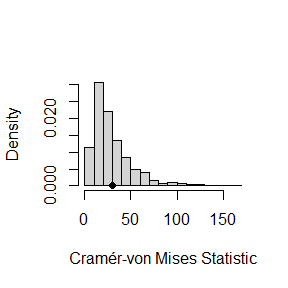

```r
# 绘制置换分布的直方图
hist(reps, main = "", freq = FALSE, xlab = "Cramér-von Mises Statistic", breaks = "scott")
points(t0, 0, cex = 1, pch = 16)  # 标出观察到的 Cramér-von Mises 统计量
```

图中的直方图显示了置换检验的统计量分布，其中黑点表示观察到的原始Cramér-von Mises 统计量位置。由于p值较高，说明在置换的样本中，观察到的统计量并没有足够显著偏离随机置换产生的统计量。这意味着基于Cramér-von Mises 统计量的置换检验没有显著性证据拒绝原假设，即大豆组和亚麻籽组的分布没有显著差异。

## 第四题（8.2）

使用置换检验方法，运用Spearman秩相关检验来测试两个变量之间是否独立。并通过cor.test（）函数来计算相同样本的p值，并与置换检验计算的显著性水平进行比较。分别用两个例子来进行比较

```r
# 生成两组相关性较强的数据
set.seed(12)
X <- rnorm(20)
Y <- X + rnorm(20)

# 计算原始的Spearman相关系数
spearman_corr_1 <- cor(X, Y, method = "spearman")
cat(paste("原始的Spearman相关系数:", spearman_corr_1, "\n"))
```

```
## 原始的Spearman相关系数: 0.601503759398496
```

```r
# 置换检验
R <- 999
# 定义用于储存的零向量
spearman_reps_1 <- numeric(R)

for (i in 1:R) {
  # 随机置换Y
  Y_permuted <- sample(Y)
  spearman_reps_1[i] <- cor(X, Y_permuted, method = "spearman")
}

# 计算置换p值
p_value_perm_1 <- mean(abs(spearman_reps_1) >= abs(spearman_corr_1))
cat(paste("置换检验的p值:", p_value_perm_1, "\n"))
```

```
## 置换检验的p值: 0.00800800800800801
```

```r
# 使用cor.test计算p值
cor_test_result_1 <- cor.test(X, Y, method = "spearman")
cat(paste("cor.test的p值:", cor_test_result_1$p.value, "\n"))
```

```
## cor.test的p值: 0.00592843424773622
```

原始的Spearman相关系数为 0.601，表明两个变量之间有较强的正相关性。 置换检验的p值为0.008，这是一个非常低的p值，表明在置换检验中，这两个变量之间的相关性是显著的。 cor.test 的p值为0.0059，与置换检验的p值非常接近，同样表明相关性显著。 综上，无论是通过置换检验还是cor.test，这两个变量都显示了显著的正相关性。两种检验方法（置换检验和cor.test）的结果是一致的。

```r
# 生成两组相关性较弱的数据
set.seed(1234)
x <- rnorm(20)
y <- rnorm(20)

# 计算原始的Spearman相关系数
spearman_corr_2 <- cor(x, y, method = "spearman")
cat(paste("原始的Spearman相关系数:", spearman_corr_2, "\n"))
```

```
## 原始的Spearman相关系数: -0.279699248120301
```

```r
# 置换检验
R <- 999
# 定义用于储存的零向量
spearman_reps_2 <- numeric(R)

for (i in 1:R) {
  # 随机置换y
  y_permuted <- sample(y)
  spearman_reps_2[i] <- cor(x, y_permuted, method = "spearman")
}

# 计算置换p值
p_value_perm_2 <- mean(abs(spearman_reps_2) >= abs(spearman_corr_2))
cat(paste("置换检验的p值:", p_value_perm_2, "\n"))
```

```
## 置换检验的p值: 0.227227227227227
```

```r
# 使用cor.test计算p值
cor_test_result_2 <- cor.test(x, y, method = "spearman")
cat(paste("cor.test的p值:", cor_test_result_2$p.value, "\n"))
```

```
## cor.test的p值: 0.23148034369735
```

原始的Spearman相关系数为 -0.280，这表明两个变量之间存在弱负相关。 置换检验的p值为0.227，表示在置换检验中，两个变量之间的相关性不显著。 cor.test的p值为0.231，与置换检验的p值非常接近，也表明相关性在统计上不显著。 综上，两个变量之间的弱负相关性不足以达到统计显著性水平，两个变量之间没有显著相关性。两个检验方法（置换检验和cor.test）的结果仍是一致的。

# 第七次作业

## 第一题（9.3）

使用Metropolis-Hastings样本生成器生成服从标准柯西分布的随机变量，去掉前1000项后与标准柯西分布比较十分位数。再用Gelman-Rubin方法来监控链的收敛性。

将迭代次数设置为20000.

```r
# 加载所需包
library(stats)

# 定义标准柯西密度函数
f <- function(x) {
  return(1 / (pi * (1 + x^2)))
}

# 定义Metropolis-Hastings样本生成器
metropolis_hastings <- function(n, x0, sd) {
  x <- numeric(n)
  x[1] <- x0

  for (i in 2:n) {
    y <- rnorm(1, mean = x[i-1], sd = sd)

    # 计算接受概率
    p <- min(1, f(y) / f(x[i-1]))

    # 接受或拒绝样本
    if (runif(1) < p) {
      x[i] <- y
    } else {
      x[i] <- x[i-1]
    }
  }
  return(x)
}


# 设置随机种子以便复现
set.seed(123)
# 迭代次数
n <- 20000
# 去掉链条的数量
m <- 1000
# 初始值
x0 <- 0
# 分布的标准差
sd <- 1
# 运行Metropolis-Hastings样本生成器
MH <- metropolis_hastings(n, x0, sd)

# 丢弃前1000项后的链条
MH_1 <- MH[-(1:m)]

# 生成的Metropolis-Hastings样本的十分位数
generated_quantile <- quantile(MH_1, probs = seq(0.1, 0.9, by = 0.1))

# 标准柯西分布的十分位数
standard_quantile <- qcauchy(seq(0.1, 0.9, by = 0.1))

# 输出结果
cat("生成的Metropolis-Hastings样本的十分位数：\n")
```

```
## 生成的Metropolis-Hastings样本的十分位数：
```

```r
print(generated_quantile)
```

```
##         10%         20%         30%         40%         50%         60%
## -3.47907791 -1.62394366 -0.87746882 -0.42661965 -0.09802669  0.21743713
##         70%         80%         90%
##  0.60145022  1.12845643  2.49160033
```

```r
cat("\n标准柯西分布的十分位数：\n")
```

```
##
## 标准柯西分布的十分位数：
```

```r
print(standard_quantile)
```

```
## [1] -3.0776835 -1.3763819 -0.7265425 -0.3249197  0.0000000  0.3249197  0.7265425
## [8]  1.3763819  3.0776835
```

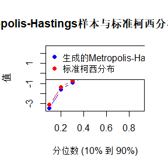

```r
# 可视化比较
plot(seq(0.1, 0.9, by = 0.1), generated_quantile, type = "b", col = "blue", pch = 19,
     xlab = "分位数 (10% 到 90%)", ylab = "值", main = "生成的Metropolis-Hastings样本与标准柯西分布的十分位数比较")
lines(seq(0.1, 0.9, by = 0.1), standard_quantile, type = "b", col = "red", pch = 19)
legend("topleft", legend = c("生成的Metropolis-Hastings样本分布", "标准柯西分布"), col = c("blue", "red"), pch = 19)
```

使用Gelman-Rubin方法来监控链的收敛性

```r
# 加载所需包
library(coda)

# 设置参数
n_chains <- 5 # 链的数量

# 生成多个独立链
chains <- list()
for (i in 1:n_chains) {
  x0 <- rnorm(1, mean = 0, sd = 5) # 每个链有不同的初始值
  chains[[i]] <- metropolis_hastings(n, x0, sd)
}

# 转换为mcmc对象，并丢弃前1000个样本
mcmc_chains <- mcmc.list(lapply(chains, function(chain) mcmc(chain[-(1:m)])))

# 计算Gelman-Rubin统计量
GR_result <- gelman.diag(mcmc_chains)

# 输出Gelman-Rubin诊断结果
cat("Gelman-Rubin 诊断结果：\n")
```

```
## Gelman-Rubin 诊断结果：
```

```r
print(GR_result)
```

```
## Potential scale reduction factors:
##
##      Point est. Upper C.I.
## [1,]       1.26       1.83
```

```r
# 检查收敛性
if (all(GR_result$psrf < 1.2)) {
  cat("\n链已收敛至目标分布 (R_hat < 1.2)。\n")
} else {
  cat("\n链尚未收敛，请增加迭代次数。\n")
}
```

```
##
## 链尚未收敛，请增加迭代次数。
```

可见，生成的观测值不够拟合标准柯西分布，经过Gelman-Rubin方法的检验，应该增加迭代次数。

将迭代次数设置为40000

```r
# 设置随机种子以便复现
set.seed(123)
# 迭代次数
n <- 40000

# 运行Metropolis-Hastings样本生成器
MH <- metropolis_hastings(n, x0, sd)

# 丢弃前1000项后的链条
MH_1 <- MH[-(1:m)]

# 生成的Metropolis-Hastings样本的十分位数
generated_quantile <- quantile(MH_1, probs = seq(0.1, 0.9, by = 0.1))

# 标准柯西分布的十分位数
standard_quantile <- qcauchy(seq(0.1, 0.9, by = 0.1))

# 输出结果
cat("生成的Metropolis-Hastings样本的十分位数：\n")
```

```
## 生成的Metropolis-Hastings样本的十分位数：
```

```r
print(generated_quantile)
```

```
##          10%          20%          30%          40%          50%          60%
## -3.121906551 -1.441071356 -0.740404372 -0.339750016 -0.005400111  0.327145423
##          70%          80%          90%
##  0.744486493  1.443952167  3.945170027
```

```r
cat("\n标准柯西分布的十分位数：\n")
```

```
##
## 标准柯西分布的十分位数：
```

```r
print(standard_quantile)
```

```
## [1] -3.0776835 -1.3763819 -0.7265425 -0.3249197  0.0000000  0.3249197  0.7265425
## [8]  1.3763819  3.0776835
```

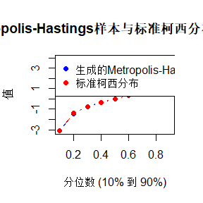

```r
# 可视化比较
plot(seq(0.1, 0.9, by = 0.1), generated_quantile, type = "b", col = "blue", pch = 19,
     xlab = "分位数 (10% 到 90%)", ylab = "值", main = "生成的Metropolis-Hastings样本与标准柯西分布的十分位数比较")
lines(seq(0.1, 0.9, by = 0.1), standard_quantile, type = "b", col = "red", pch = 19)
legend("topleft", legend = c("生成的Metropolis-Hastings样本分布", "标准柯西分布"), col = c("blue", "red"), pch = 19)
```

再次使用Gelman-Rubin方法来监控链的收敛性

```r
# 生成多个独立链
chains <- list()
for (i in 1:n_chains) {
  x0 <- rnorm(1, mean = 0, sd = 5) # 每个链有不同的初始值
  chains[[i]] <- metropolis_hastings(n, x0, sd)
}

# 转换为mcmc对象，并丢弃前1000个样本
mcmc_chains <- mcmc.list(lapply(chains, function(chain) mcmc(chain[-(1:m)])))

# 计算Gelman-Rubin统计量
GR_result <- gelman.diag(mcmc_chains)

# 输出Gelman-Rubin诊断结果
cat("Gelman-Rubin 诊断结果：\n")
```

```
## Gelman-Rubin 诊断结果：
```

```r
print(GR_result)
```

```
## Potential scale reduction factors:
##
##      Point est. Upper C.I.
## [1,]       1.09       1.16
```

```r
# 检查收敛性
if (all(GR_result$psrf < 1.2)) {
  cat("\n链已收敛至目标分布 (R_hat < 1.2)。\n")
} else {
  cat("\n链尚未收敛，请增加迭代次数。\n")
}
```

```
##
## 链已收敛至目标分布 (R_hat < 1.2)。
```

可见，增加迭代次数后，拟合程度大大提高。

## 第二题（9.8）

使用Gibbs样本生成器生成一个目标联合密度为
$$f(x,y)$$
的链条，不妨取a=1，b=1，n=10

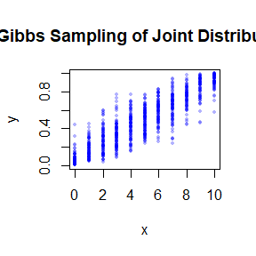

```r
# 参数设置
a <- 1
b <- 1
n <- 10
# 设置总采样次数
N <- 1000

# 初始化x和y（取x=0,y=0.5）
x <- 0
y <- 0.5

# 创建零向量来存储采样结果
x_samples <- numeric(N)
y_samples <- numeric(N)

# 进行Gibbs采样
for (i in 1:N) {
  # 在给定当前y值的情况下，从Binomial(n,y)中采样x
  x <- rbinom(1, n, y)

  # 使用新的x值，从Beta(x+a,n-x+b)中采样y
  y <- rbeta(1, x + a, n - x + b)

  # 存储采样结果
  x_samples[i] <- x
  y_samples[i] <- y
}

# 绘制出采样结果的联合分布图
plot(x_samples, y_samples, pch = 16, cex = 0.5, col = rgb(0, 0, 1, 0.3),
     xlab = "x", ylab = "y", main = "Gibbs Sampling of Joint Distribution")
```

使用Gelman-Rubin方法来监控链的收敛性

```r
# 加载所需包
library(coda)

# 参数设置
a <- 1
b <- 1
n <- 10
# 设置每条链的初始采样数
N <- 1000
# 设置链的数量
n_chains <- 5

# 初始化链，选择多个起点来增加独立性
chains <- vector("list", n_chains)
for (i in 1:n_chains) {
  chains[[i]] <- list(x = numeric(N), y = numeric(N))
  # 在0到n上随机选择初始x
  chains[[i]]$x[1] <- sample(0:n, 1)
  # 在(0, 1)上随机选择初始y
  chains[[i]]$y[1] <- runif(1, 0, 1)
}

# 定义收敛性检查的标志
converged <- FALSE

# 进行Gibbs采样与收敛监控
while (!converged) {
  # 对每条链进行 Gibbs 采样
  for (i in 1:n_chains) {
    x <- chains[[i]]$x
    y <- chains[[i]]$y

    for (j in 2:N) {
      # 采样x|y
      x[j] <- rbinom(1, n, y[j - 1])
       # 采样y|x
      y[j] <- rbeta(1, x[j] + a, n - x[j] + b)
    }

    # 更新链的值
    chains[[i]]$x <- x
    chains[[i]]$y <- y
  }

  # 转换链的数据为 mcmc.list 格式，以便使用 coda 包的收敛性检查函数
  x_chains <- mcmc.list(lapply(chains, function(chain) mcmc(chain$x)))
  y_chains <- mcmc.list(lapply(chains, function(chain) mcmc(chain$y)))

  # 使用 Gelman-Rubin 诊断
  GR_x <- gelman.diag(x_chains, autoburnin = FALSE)
  GR_y <- gelman.diag(y_chains, autoburnin = FALSE)

  # 检查 R^ 值是否小于 1.2
  if (GR_x$psrf[1] < 1.2 && GR_y$psrf[1] < 1.2) {
    converged <- TRUE
  } else {
    # 如果没有收敛，则增加样本数
    N <- N + 1000
    for (i in 1:n_chains) {
      chains[[i]]$x <- c(chains[[i]]$x, numeric(1000))
      chains[[i]]$y <- c(chains[[i]]$y, numeric(1000))
    }
  }
}

# 输出最终的Gelman-Rubin诊断结果
cat("最终的迭代次数:",N)
```

```
## 最终的迭代次数: 1000
```

```r
print("链已收敛至目标分布 (R_hat < 1.2)。")
```

```
## [1] "链已收敛至目标分布 (R_hat < 1.2)。"
```

```r
print(GR_x)
```

```
## Potential scale reduction factors:
##
##      Point est. Upper C.I.
## [1,]       1.03       1.07
```

```r
print(GR_y)
```

```
## Potential scale reduction factors:
##
##      Point est. Upper C.I.
## [1,]       1.03       1.07
```

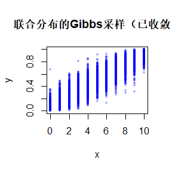

```r
# 绘制收敛后的联合分布图
x_samples <- unlist(lapply(chains, function(chain) chain$x))
y_samples <- unlist(lapply(chains, function(chain) chain$y))
plot(x_samples, y_samples, pch = 16, cex = 0.5, col = rgb(0, 0, 1, 0.3),
     xlab = "x", ylab = "y", main = "联合分布的Gibbs采样（已收敛）")
```

## 证明题

$$a(s, r) = \min \left\{ \frac{f(r)
g(s|r)}{f(s) g(r|s)}, 1 \right\}$$

$$K(r, s) = I(s \leq r) a(r, s) g(s|r) +
I(s > r) \left[ 1 - \int a(r, s) g(s|r) \right]$$

$$① 当 s = r 时，有
\quad K(r, r) = k(r, r) = 1 - \int a(r, r) g(r|r)$$

$$因此，k(r, r) f(r) = k(r, r) \cdot
f(r)$$

$$即 K(s, r) f(s) = k(r, s) f(r) 在 r = s
时成立$$

$$② s \neq
r, 且 f(s) g(r|s) > f(r) g(s|r)$$

$$此时 a(r, s) = 1, a(s, r) = \frac{f(r)
g(s|r)}{f(s) g(r|s)}$$

$$f(s) g(r|s) a(s, r) = f(r) g(s|r)
\frac{f(s) g(r|s)}{f(s) g(r|s)} = f(r) g(s|r) a(r, s)$$

$$即 f(s) \cdot K(s, r) = f(r) K(r,
s)$$

$$③ s \neq r, f(s) g(r|s) < f(r) g(s|r)
时$$

$$同理可得有
\quad K(s, r) f(s) = k(r, s) f(r)$$

$$综上，K(s, r) f(s) = k(r, s) f(r)
得证$$

# 第八次作业

## 第一题（11.3）

$$\sum_{k=0}^\infty \frac{(-1)^k}{k! \cdot
2^k} \frac{\|a\|^{2k+2}}{(2k+1)(2k+2)}
\cdot \frac{\Gamma\left(\frac{d+1}{2}\right) \Gamma\left(k +
\frac{3}{2}\right)}{\Gamma\left(k + \frac{d}{2} + 1\right)}$$

### (a)给出一个函数来计算第k项

```r
# 加载必要的包，用于计算伽马函数Gamma
library(gsl)

# 定义计算第k项的函数
b_k <- function(k, d, a) {

  # 计算欧几里得范数a
  norm_a <- sqrt(sum(a^2))

  # 计算公式的分子与分母
  numerator <- (-1)^k * norm_a^(2 * k + 2) * gamma((d + 1) / 2) * gamma(k + 3 / 2)
  denominator <- factorial(k) * 2^k * (2 * k + 1) * (2 * k + 2) * gamma(k + d / 2 + 1)

  # 返回结果
  return(numerator/denominator)
}
```

### (b)给出可以计算级数和的函数

```r
S <- function(d, a, tol = 1e-20) {
  # 初始化变量
  sum_result <- 0
  k <- 0

  repeat {
    # 计算第 k 项
    term <- b_k(k, d, a)

    # 累加到总和中
    sum_result <- sum_result + term

    # 检查收敛条件
    if (abs(term) < tol) break

    # 增加迭代次数
    k <- k + 1
  }

  # 返回结果
  return(sum_result)
}
```

### (c)计算级数和

$$a = \begin{pmatrix} 1 \\ 2
\end{pmatrix}$$
，

```r
# 设置向量a和维度d
a <- c(1, 2)
d <- length(a)

# 计算级数和
result <- S(d, a)
cat("级数的和为：", result, "\n")
```

```
## 级数的和为： 1.532164
```

## 第二题（11.5）

$$对于\frac{2
\Gamma\left(\frac{k}{2}\right)}{\sqrt{\pi}(k-1)\Gamma\left(\frac{k-1}{2}\right)}
\int_{0}^{c_k-1} \left(1 + \frac{u^2}{k-1}\right)^{-k/2} \, du
=
\frac{2 \Gamma\left(\frac{k+1}{2}\right)}{\sqrt{\pi
k}\Gamma\left(\frac{k}{2}\right)}
\int_{0}^{c_k} \left(1 + \frac{u^2}{k}\right)^{-(k+1)/2} \, du,c_k =
\sqrt{\frac{a^2 k}{k + 1 -
a^2}}.$$
设计函数计算不同k时a的解。（考虑重根的情况。） 要求与11.4中的A（k）进行比较，因此也应该对11.4进行模拟. 在k=4:25,100,500,1000时，求
$$S_{k-1}(a) =
P\left(t(k-1) > \sqrt{\frac{a^2 (k-1)}{k - a^2}}\right)$$
$$S_k(a) = P\left(t(k) > \sqrt{\frac{a^2
k}{k + 1 - a^2}}\right)$$
在
$$(0,
\sqrt{k})$$
上的交点，使用pt（ ，df）函数。

```r
library(dplyr)
# 使用 knitr::kable 显示完整表格
library(knitr)


# 定义 k 的取值
k_values <- c(4:25, 100, 500, 1000)

# 初始化一个列表储存11.4中的临界值a(A_k_list)
A_k_list <- vector("list", length(k_values))
names(A_k_list) <- k_values

# 初始化一个列表储存11.5中求解得到的a
critical_a_11_5_list <- vector("list", length(k_values))
names(critical_a_11_5_list) <- k_values

# 定义一个能计算11.5中公式的函数
compute_f_integral <- function(a, k) {
  if (a >= sqrt(k)) {
    return(Inf)
  }

  # 计算 c_k 和 c_{k-1}
  c_k <- sqrt((a^2 * k) / (k + 1 - a^2))
  c_k_minus_1 <- sqrt((a^2 * (k - 1)) / (k - a^2))

  # 使用对数形式计算左边的系数，防止数据溢出
  log_coef_left <- log(2) + lgamma(k / 2) - (0.5 * log(pi)) - (0.5 * log(k - 1)) - lgamma((k - 1) / 2)
  coef_left <- exp(log_coef_left)

  # 定义左边的被积函数
  integrand_left <- function(u) {
    (1 + (u^2) / (k - 1))^(-k / 2)
  }

  # 计算左边的积分
  integral_left <- tryCatch({
    integrate(integrand_left, lower = 0.0, upper = c_k_minus_1, rel.tol = 1e-12)$value
  }, error = function(e) {
    warning(paste("积分左侧失败，对于 k =", k, "a =", a))
    return(NA)
  })

  # 计算左边公式
  left_side <- coef_left * integral_left

  # 使用对数形式计算右边的系数
  log_coef_right <- log(2) + lgamma((k + 1) / 2) - (0.5 * log(pi * k)) - lgamma(k / 2)
  coef_right <- exp(log_coef_right)

  # 定义右边的被积函数
  integrand_right <- function(u) {
    (1 + (u^2) / k)^(-(k + 1) / 2)
  }

  # 计算右边的积分
  integral_right <- tryCatch({
    integrate(integrand_right, lower = 0.0, upper = c_k, rel.tol = 1e-12)$value
  }, error = function(e) {
    warning(paste("积分右侧失败，对于 k =", k, "a =", a))
    return(NA)
  })

  # 计算右边公式
  right_side <- coef_right * integral_right

  # 返回左右之差
  return(left_side - right_side)
}

  # 定义一个求出解a的函数
find_solution_11_5_integral <- function(k) {
  f <- function(a) {
    compute_f_integral(a, k)
  }

  #确定上下界，防止出现分母为0和a=0的情况
  lower_a <- 0.0001
  upper_a <- sqrt(k) - 0.0001

  # 自动搜索符号变化的区间
  a_seq <- seq(lower_a, upper_a, length.out = 1000)
  f_values <- sapply(a_seq, f)

  # 查找符号变化的位置
  sign_changes <- which(diff(sign(f_values)) != 0)

  if (length(sign_changes) == 0) {
    warning(paste("未在区间内找到交点，对于 k =", k))
    return(NA)
  }

  # 初始化一个向量存储所有根
  roots <- numeric(0)

  # 遍历所有符号变化的位置，寻找根
  for (idx in sign_changes) {
    # 定义当前符号变化的子区间
    lower_a_new <- a_seq[idx]
    upper_a_new <- a_seq[idx + 1]

    # 输出调试信息
    cat("k =", k,
        "a_lower =", lower_a_new, "f(a_lower) =", f(lower_a_new), "\n")
    cat("k =", k,
        "a_upper =", upper_a_new, "f(a_upper) =", f(upper_a_new), "\n")

    # 使用uniroot寻找根
    root <- tryCatch({
      uniroot(f, lower = lower_a_new, upper = upper_a_new, tol = 1e-10)$root
    }, error = function(e) {
      warning(paste("无法找到交点在 a =", lower_a_new, "到", upper_a_new, "之间，对于 k =", k))
      return(NA)
    })

    # 仅添加非NA的根，并避免重复
    if (!is.na(root) && !any(abs(roots - root) < 1e-6)) {
      roots <- c(roots, root)
    }
  }

  # 如果没有有效根，返回 NA
  if (length(roots) == 0) {
    return(NA)
  }

  return(roots)
}

# 定义一个能计算11.4中交点A（k）的函数
Intersection <- function(k) {
  # 定义函数差异 f(a) = S_{k-1}(a) - S_k(a)
  f <- function(a) {
    # 确保 a < sqrt(k) 以避免分母为零或负数
    if (a >= sqrt(k)) {
      return(Inf)
    }

    # 计算 a_{k-1}
    a_km1 <- a * sqrt((k - 1) / (k - a^2))
    # 计算 S_{k-1}(a) = P(t(k-1) > a_km1)
    S_km1 <- 1 - pt(a_km1, df = k - 1)

    # 计算 a_k
    a_k <- a * sqrt(k / (k + 1 - a^2))
    # 计算 S_k(a) = P(t(k) > a_k)
    S_k <- 1 - pt(a_k, df = k)

    # 返回差异
    return(S_km1 - S_k)
  }

  # 设置a的搜索区间，防止出现分母为0和a=0的情况
  lower_a <- 0.0001
  upper_a <- sqrt(k) - 0.0001

  # 生成a的序列以检测符号变化
  a_seq <- seq(lower_a, upper_a, length.out = 1000)
  f_values <- sapply(a_seq, f)

  # 查找符号变化的位置
  sign_changes <- which(diff(sign(f_values)) != 0)

  if (length(sign_changes) == 0) {
    warning(paste("未在区间内找到交点，对于 k =", k))
    return(NA)
  }

  # 初始化一个向量存储所有根
  roots <- numeric(0)

  # 遍历所有符号变化的位置，寻找根
  for (idx in sign_changes) {
    # 定义当前符号变化的子区间
    lower_a_new <- a_seq[idx]
    upper_a_new <- a_seq[idx + 1]

    # 使用 uniroot 寻找根
    root <- tryCatch({
      uniroot(f, lower = lower_a_new, upper = upper_a_new)$root
    }, error = function(e) {
      warning(paste("无法找到交点在 a =", lower_a_new, "到", upper_a_new, "之间，对于 k =", k))
      return(NA)
    })

    # 仅添加非NA的根，并避免重复
    if (!is.na(root) && !any(abs(roots - root) < 1e-6)) {
      roots <- c(roots, root)
    }
  }

  # 如果没有有效根，返回 NA
  if (length(roots) == 0) {
    return(NA)
  }

  return(roots)
}

# 对每个 k 值找到对应的所有临界值 a (11.4)
for (i in seq_along(k_values)) {
  k <- k_values[i]
  cat("\n正在处理11.4的k=", k, "...\n")
  a_roots <- Intersection(k)
  A_k_list[[i]] <- a_roots
}
```

```
##
## 正在处理11.4的k= 4 ...
##
## 正在处理11.4的k= 5 ...
##
## 正在处理11.4的k= 6 ...
##
## 正在处理11.4的k= 7 ...
##
## 正在处理11.4的k= 8 ...
##
## 正在处理11.4的k= 9 ...
##
## 正在处理11.4的k= 10 ...
##
## 正在处理11.4的k= 11 ...
##
## 正在处理11.4的k= 12 ...
##
## 正在处理11.4的k= 13 ...
##
## 正在处理11.4的k= 14 ...
##
## 正在处理11.4的k= 15 ...
##
## 正在处理11.4的k= 16 ...
##
## 正在处理11.4的k= 17 ...
##
## 正在处理11.4的k= 18 ...
##
## 正在处理11.4的k= 19 ...
##
## 正在处理11.4的k= 20 ...
##
## 正在处理11.4的k= 21 ...
##
## 正在处理11.4的k= 22 ...
##
## 正在处理11.4的k= 23 ...
##
## 正在处理11.4的k= 24 ...
##
## 正在处理11.4的k= 25 ...
##
## 正在处理11.4的k= 100 ...
##
## 正在处理11.4的k= 500 ...
##
## 正在处理11.4的k= 1000 ...
```

```r
# 手动验证 f(a,k) 在已知解处是否为零 (11.4)
verify_f_11_4 <- function(a, k) {
  # 定义函数差异 f(a) = S_{k-1}(a) - S_k(a)
  f <- function(a) {
    if (a >= sqrt(k)) {
      return(Inf)
    }

    a_km1 <- a * sqrt((k - 1) / (k - a^2))
    S_km1 <- 1 - pt(a_km1, df = k - 1)

    a_k <- a * sqrt(k / (k + 1 - a^2))
    S_k <- 1 - pt(a_k, df = k)

    return(S_km1 - S_k)
  }

  f(a)
}

for (i in seq_along(k_values)) {
  k <- k_values[i]
  a_roots <- A_k_list[[i]]
  if (!all(is.na(a_roots))) {
    for (a_star in a_roots) {
      f_at_a_star <- verify_f_11_4(a_star, k)
      cat("\n验证11.4: k =", k, "a =", a_star, "f(a) =", f_at_a_star, "\n")
    }
  }
}
```

```
##
## 验证11.4: k = 4 a = 1.492102 f(a) = 9.671906e-09
##
## 验证11.4: k = 5 a = 1.533559 f(a) = 4.69813e-10
##
## 验证11.4: k = 6 a = 1.562745 f(a) = -1.724352e-09
##
## 验证11.4: k = 7 a = 1.58443 f(a) = -2.09986e-09
##
## 验证11.4: k = 8 a = 1.601183 f(a) = -2.82807e-09
##
## 验证11.4: k = 9 a = 1.614517 f(a) = -2.586742e-09
##
## 验证11.4: k = 10 a = 1.625384 f(a) = -2.666562e-09
##
## 验证11.4: k = 11 a = 1.63441 f(a) = -2.118249e-09
##
## 验证11.4: k = 12 a = 1.642027 f(a) = -2.34855e-09
##
## 验证11.4: k = 13 a = 1.648541 f(a) = -1.59688e-09
##
## 验证11.4: k = 14 a = 1.654176 f(a) = -1.885599e-09
##
## 验证11.4: k = 15 a = 1.659097 f(a) = -4.061994e-10
##
## 验证11.4: k = 16 a = 1.663436 f(a) = -1.818271e-09
##
## 验证11.4: k = 17 a = 1.667283 f(a) = -2.244296e-10
##
## 验证11.4: k = 18 a = 1.670727 f(a) = -1.580292e-09
##
## 验证11.4: k = 19 a = 1.67382 f(a) = -1.488727e-09
##
## 验证11.4: k = 20 a = 1.676617 f(a) = -1.488423e-09
##
## 验证11.4: k = 21 a = 1.679154 f(a) = -2.674463e-10
##
## 验证11.4: k = 22 a = 1.681473 f(a) = -6.029738e-10
##
## 验证11.4: k = 23 a = 1.683598 f(a) = -1.096289e-09
```

[output cut: 25 more lines]

```
## 验证11.4: k = 100 a = 7.077036 f(a) = 0
##
## 验证11.4: k = 500 a = 1.729746 f(a) = -2.473577e-13
##
## 验证11.4: k = 500 a = 7.27453 f(a) = 0
##
## 验证11.4: k = 500 a = 7.319296 f(a) = 0
##
## 验证11.4: k = 500 a = 7.408828 f(a) = 0
##
## 验证11.4: k = 500 a = 7.453593 f(a) = 0
##
## 验证11.4: k = 1000 a = 1.730897 f(a) = 9.769963e-15
##
## 验证11.4: k = 1000 a = 7.248919 f(a) = 0
```

```r
for (i in seq_along(k_values)) {
  k <- k_values[i]
  cat("\n正在处理11.5 的 k =", k, "...\n")
  a_roots_11_5 <- find_solution_11_5_integral(k)
  critical_a_11_5_list[[i]] <- a_roots_11_5
}
```

```
##
## 正在处理11.5 的 k = 4 ...
## k = 4 a_lower = 1.491442 f(a_lower) = -3.420114e-05
## k = 4 a_upper = 1.493444 f(a_upper) = 6.951445e-05
##
## 正在处理11.5 的 k = 5 ...
## k = 5 a_lower = 1.533203 f(a_lower) = -9.510503e-06
## k = 5 a_upper = 1.535441 f(a_upper) = 5.024221e-05
##
## 正在处理11.5 的 k = 6 ...
## k = 6 a_lower = 1.561859 f(a_lower) = -1.41784e-05
## k = 6 a_upper = 1.564311 f(a_upper) = 2.507892e-05
##
## 正在处理11.5 的 k = 7 ...
## k = 7 a_lower = 1.583723 f(a_lower) = -7.472173e-06
## k = 7 a_upper = 1.586372 f(a_upper) = 2.054406e-05
##
## 正在处理11.5 的 k = 8 ...
## k = 8 a_lower = 1.599648 f(a_lower) = -1.148032e-05
## k = 8 a_upper = 1.602479 f(a_upper) = 9.692799e-06
##
## 正在处理11.5 的 k = 9 ...
## k = 9 a_lower = 1.612605 f(a_lower) = -1.061457e-05
## k = 9 a_upper = 1.615608 f(a_upper) = 6.052802e-06
##
## 正在处理11.5 的 k = 10 ...
## k = 10 a_lower = 1.62387 f(a_lower) = -6.469903e-06
## k = 10 a_upper = 1.627035 f(a_upper) = 7.052428e-06
##
## 正在处理11.5 的 k = 11 ...
## k = 11 a_lower = 1.633414 f(a_lower) = -3.369802e-06
## k = 11 a_upper = 1.636734 f(a_upper) = 7.865679e-06
##
## 正在处理11.5 的 k = 12 ...
## k = 12 a_lower = 1.640166 f(a_lower) = -5.117628e-06
## k = 12 a_upper = 1.643633 f(a_upper) = 4.413457e-06
##
## 正在处理11.5 的 k = 13 ...
## k = 13 a_lower = 1.645786 f(a_lower) = -6.270886e-06
## k = 13 a_upper = 1.649395 f(a_upper) = 1.943362e-06
```

[output cut: 59 more lines]

```
## k = 100 a_upper = 1.721787 f(a_upper) = 3.326308e-08
## k = 100 a_lower = 6.3263 f(a_lower) = 8.437695e-15
## k = 100 a_upper = 6.33631 f(a_upper) = -3.441691e-15
##
## 正在处理11.5 的 k = 500 ...
## k = 500 a_lower = 1.72358 f(a_lower) = -6.684447e-09
## k = 500 a_upper = 1.745963 f(a_upper) = 1.724646e-08
## k = 500 a_lower = 6.356833 f(a_lower) = 2.520206e-14
## k = 500 a_upper = 6.379216 f(a_upper) = -9.65894e-15
##
## 正在处理11.5 的 k = 1000 ...
## k = 1000 a_lower = 1.709428 f(a_lower) = -5.866792e-09
## k = 1000 a_upper = 1.741083 f(a_upper) = 2.709036e-09
## k = 1000 a_lower = 6.267638 f(a_lower) = 2.564615e-14
## k = 1000 a_upper = 6.299292 f(a_upper) = -1.032507e-14
```

```r
# 手动验证 f(a,k) 在已知解处是否为零 (11.5)
for (i in seq_along(k_values)) {
  k <- k_values[i]
  a_roots <- critical_a_11_5_list[[i]]
  if (!all(is.na(a_roots))) {
    for (a_star in a_roots) {
      f_at_a_star <- compute_f_integral(a_star, k)
      cat("\n验证11.5: k =", k, "a =", a_star, "f(a) =", f_at_a_star, "\n")
    }
  }
}
```

```
##
## 验证11.5: k = 4 a = 1.492103 f(a) = 2.109424e-14
##
## 验证11.5: k = 5 a = 1.533559 f(a) = 7.771561e-16
##
## 验证11.5: k = 6 a = 1.562745 f(a) = -3.318457e-13
##
## 验证11.5: k = 7 a = 1.584429 f(a) = 0
##
## 验证11.5: k = 8 a = 1.601182 f(a) = -1.432188e-14
##
## 验证11.5: k = 9 a = 1.614516 f(a) = -1.387779e-14
##
## 验证11.5: k = 10 a = 1.625383 f(a) = -4.440892e-16
##
## 验证11.5: k = 11 a = 1.634409 f(a) = 0
##
## 验证11.5: k = 12 a = 1.642026 f(a) = -2.020606e-14
##
## 验证11.5: k = 13 a = 1.64854 f(a) = -1.121325e-14
##
## 验证11.5: k = 14 a = 1.654174 f(a) = -1.809664e-14
##
## 验证11.5: k = 15 a = 1.659096 f(a) = -8.881784e-16
##
## 验证11.5: k = 16 a = 1.663433 f(a) = -1.110223e-16
##
## 验证11.5: k = 17 a = 1.667283 f(a) = -1.110223e-16
##
## 验证11.5: k = 18 a = 1.670724 f(a) = 0
##
## 验证11.5: k = 19 a = 1.673817 f(a) = -2.087219e-14
##
## 验证11.5: k = 20 a = 1.676614 f(a) = 1.854072e-14
##
## 验证11.5: k = 21 a = 1.679154 f(a) = -1.110223e-16
##
## 验证11.5: k = 21 a = 4.572079 f(a) = 0
##
## 验证11.5: k = 22 a = 1.681471 f(a) = 1.110223e-16
##
## 验证11.5: k = 23 a = 1.683594 f(a) = 1.354472e-14
##
## 验证11.5: k = 23 a = 4.728525 f(a) = 0
##
## 验证11.5: k = 24 a = 1.685546 f(a) = 1.176836e-14
##
## 验证11.5: k = 25 a = 1.687347 f(a) = 1.110223e-16
##
## 验证11.5: k = 25 a = 4.998644 f(a) = 0
##
## 验证11.5: k = 100 a = 1.720599 f(a) = -2.109424e-15
##
## 验证11.5: k = 100 a = 6.331704 f(a) = 0
##
## 验证11.5: k = 500 a = 1.729745 f(a) = 2.664535e-15
##
## 验证11.5: k = 500 a = 6.373014 f(a) = 6.106227e-15
##
## 验证11.5: k = 1000 a = 1.730897 f(a) = -4.440892e-16
##
## 验证11.5: k = 1000 a = 6.297422 f(a) = -6.661338e-15
```

```r
# 将A_k_list和critical_a_11_5_list转换为长格式的数据框
# 添加一个来源列来区分是 11.4还是11.5
results_11_4 <- do.call(rbind, lapply(seq_along(k_values), function(i) {
  k <- k_values[i]
  a_vals <- A_k_list[[i]]
  if (all(is.na(a_vals))) {
    data.frame(k = k, A_k = NA, source = "11.4")
  } else {
    data.frame(k = rep(k, length(a_vals)), A_k = a_vals, source = "11.4")
  }
}))

results_11_5 <- do.call(rbind, lapply(seq_along(k_values), function(i) {
  k <- k_values[i]
  a_vals <- critical_a_11_5_list[[i]]
  if (all(is.na(a_vals))) {
    data.frame(k = k, A_k = NA, source = "11.5")
  } else {
    data.frame(k = rep(k, length(a_vals)), A_k = a_vals, source = "11.5")
  }
}))

# 合并两个数据框
results_combined <- bind_rows(results_11_4, results_11_5)

# 输出所有根
print(results_combined)
```

```
##       k      A_k source
## 1     4 1.492102   11.4
## 2     5 1.533559   11.4
## 3     6 1.562745   11.4
## 4     7 1.584430   11.4
## 5     8 1.601183   11.4
## 6     9 1.614517   11.4
## 7    10 1.625384   11.4
## 8    11 1.634410   11.4
## 9    12 1.642027   11.4
## 10   13 1.648541   11.4
## 11   14 1.654176   11.4
## 12   15 1.659097   11.4
## 13   16 1.663436   11.4
## 14   17 1.667283   11.4
```

[output cut: 57 more lines]

```r
# 先比较两道习题的第一个根
results_min_difference <- results_combined %>%
  filter(!is.na(A_k)) %>%
  group_by(k) %>%
  summarize(
    min_a_11_4 = ifelse(any(source == "11.4"), min(A_k[source == "11.4"], na.rm = TRUE), NA),
    min_a_11_5 = ifelse(any(source == "11.5"), min(A_k[source == "11.5"], na.rm = TRUE), NA),
    difference = min_a_11_5 - min_a_11_4
  )

# 输出比较结果
print(results_min_difference)
```

```
## # A tibble: 25 × 4
##        k min_a_11_4 min_a_11_5    difference
##    <dbl>      <dbl>      <dbl>         <dbl>
##  1     4       1.49       1.49  0.000000373
##  2     5       1.53       1.53  0.0000000352
##  3     6       1.56       1.56 -0.000000215
##  4     7       1.58       1.58 -0.000000397
##  5     8       1.60       1.60 -0.000000756
##  6     9       1.61       1.61 -0.000000932
##  7    10       1.63       1.63 -0.00000125
##  8    11       1.63       1.63 -0.00000125
##  9    12       1.64       1.64 -0.00000171
## 10    13       1.65       1.65 -0.00000140
## # ℹ 15 more rows
```

```r
# 使用 kable 显示所有行
kable(results_min_difference, caption = "11.4与11.5的第一个根的比较",
      format = "html",
      table.attr = "style='width:100%;'")
```

11.4与11.5的第一个根的比较

| k | min_a_11_4 | min_a_11_5 | difference |
| --- | --- | --- | --- |
| 4 | 1.492103 | 1.492103 | 4.0e-07 |
| 5 | 1.533559 | 1.533559 | 0.0e+00 |
| 6 | 1.562745 | 1.562745 | -2.0e-07 |
| 7 | 1.584430 | 1.584429 | -4.0e-07 |
| 8 | 1.601183 | 1.601182 | -8.0e-07 |
| 9 | 1.614517 | 1.614516 | -9.0e-07 |
| 10 | 1.625384 | 1.625383 | -1.2e-06 |
| 11 | 1.634410 | 1.634409 | -1.3e-06 |
| 12 | 1.642027 | 1.642026 | -1.7e-06 |
| 13 | 1.648541 | 1.648540 | -1.4e-06 |
| 14 | 1.654176 | 1.654174 | -2.0e-06 |
| 15 | 1.659097 | 1.659096 | -5.0e-07 |
| 16 | 1.663436 | 1.663433 | -2.6e-06 |
| 17 | 1.667283 | 1.667283 | -4.0e-07 |
| 18 | 1.670727 | 1.670724 | -2.9e-06 |
| 19 | 1.673820 | 1.673817 | -3.1e-06 |
| 20 | 1.676617 | 1.676614 | -3.5e-06 |
| 21 | 1.679154 | 1.679154 | -7.0e-07 |
| 22 | 1.681473 | 1.681471 | -1.8e-06 |
| 23 | 1.683598 | 1.683594 | -3.5e-06 |
| 24 | 1.685550 | 1.685546 | -3.6e-06 |
| 25 | 1.687349 | 1.687347 | -2.0e-06 |
| 100 | 1.720608 | 1.720599 | -8.7e-06 |
| 500 | 1.729746 | 1.729745 | -3.0e-07 |
| 1000 | 1.730897 | 1.730897 | 3.0e-07 |

可见两道习题的第一个根基本相同。

再优化11.4与11.5的比较（比较所有根）

```r
# 加载必要的包
library(dplyr)
library(tidyr)
# 使用 knitr::kable 显示完整表格
library(knitr)

# 为每个 k 和 source 分配根编号
results_with_id <- results_combined %>%
  group_by(k, source) %>%
  mutate(root_num = row_number()) %>%
  ungroup()

# 聚合根值为逗号分隔的字符串
results_aggregated <- results_with_id %>%
  group_by(k, source) %>%
  summarize(A_k = paste(A_k, collapse = ", "), .groups = 'drop')

# 转换为宽格式，分别为11.4和11.5创建列
results_wide <- results_aggregated %>%
  pivot_wider(
    names_from = source,
    values_from = A_k,
    names_prefix = "A_k_"
  )

# 创建最终比较表格
# 生成最终表格，仅包含 k、A_k_11.4、A_k_11.5
final_table <- results_wide %>%
  select(k, A_k_11.4, A_k_11.5)

# 使用 kable 显示所有行
kable(final_table, caption = "11.4与11.5的所有根的比较",
      format = "html",
      table.attr = "style='width:100%;'")
```

11.4与11.5的所有根的比较

| k | A_k_11.4 | A_k_11.5 |
| --- | --- | --- |
| 4 | 1.49210245438122 | 1.49210282784112 |
| 5 | 1.53355889401541 | 1.53355892921298 |
| 6 | 1.5627448107239 | 1.56274459534396 |
| 7 | 1.58442960525162 | 1.58442920842075 |
| 8 | 1.60118290707285 | 1.60118215072127 |
| 9 | 1.61451743163811 | 1.61451649923723 |
| 10 | 1.62538405339674 | 1.62538280513286 |
| 11 | 1.63440998558151 | 1.63440873472667 |
| 12 | 1.64202730135747 | 1.64202559232057 |
| 13 | 1.64854100451277 | 1.64853959972798 |
| 14 | 1.65417617485336 | 1.65417420144194 |
| 15 | 1.65909677596839 | 1.65909627703382 |
| 16 | 1.66343557235928 | 1.66343298143764 |
| 17 | 1.66728327216106 | 1.6672829048902 |
| 18 | 1.67072661350989 | 1.67072366952486 |
| 19 | 1.67382035632865 | 1.67381722354699 |
| 20 | 1.67661712178344 | 1.67661360817352 |
| 21 | 1.6791543913811 | 1.67915368749421, 4.57207857959858 |
| 22 | 1.68147292019575 | 1.68147116064306 |
| 23 | 1.6835975955032, 4.77652979549165 | 1.68359406629175, 4.72852547593897 |
| 24 | 1.6855495386977, 4.85965002021648 | 1.68554592322554 |
| 25 | 1.68734864610251, 4.93984234234234 | 1.68734660622099, 4.99864405940031 |
| 100 | 1.72060780696292, 6.9368981981982, 6.94690800800801, 6.97693743743744, 7.01697667667668, 7.0369962962963, 7.05701591591592, 7.07703553553554 | 1.72059912948655, 6.33170377782623 |
| 500 | 1.72974570665865, 7.27453035723155, 7.31929608250682, 7.40882753305736, 7.45359325833263 | 1.72974536047427, 6.37301413920839 |
| 1000 | 1.73089699517073, 7.24891886064623 | 1.73089732702456, 6.29742172384331 |

可见，两道习题的第一个根基本相同，即临界值基本相同；但由于根查找方法的不同、数值精度问题、算法的稳定性等因素，以及k的不断增大，在后续可能存在的重根上有略微差异。

## 第三题

$$T_1,…,T_n是从以λ$$
为期望的指数分布中抽取的独立同分布样本对右截尾的观察值
$$Y_i = T_i \cdot \mathbb{I}(T_i \leq \tau) + \tau
\cdot \mathbb{I}(T_i > \tau), \quad i = 1, 2, \dots, n ;
\tau=1$$
,分别用E-M算法和MLE估计
$$λ$$
并比较。 最大似然估计：假设数据未截尾，
$$\lambda$$
的MLE估计为：
$$\hat{\lambda}_{\text{MLE}} = \frac{1}{\bar{Y}},
\quad \bar{Y} = \text{平均观测值}$$

E-M算法：在第k次迭代中，更新
$$\lambda^{(k+1)}$$
的公式为：
$$\lambda^{(k+1)} =
\frac{n_{\text{uncensored}}}{\sum_{i=1}^{n_{\text{uncensored}}} Y_i} +
\frac{n_{\text{censored}}}{\sum_{i=1}^{n_{\text{censored}}} \left(\tau +
\frac{1}{\lambda^{(k)}}\right)}$$

```r
# 输入观测数据
Y <- c(0.54, 0.48, 0.33, 0.43, 1.00, 1.00, 0.91, 1.00, 0.21, 0.85)

# 右截尾的阈值
tau <- 1

# 使用E-M算法估计 λ
EM <- function(Y, tau, max_iter = 1000, tol = 1e-6) {
  # 初始化 λ
  lambda_est <- 1 / mean(Y)

  for (iter in 1:max_iter) {
    # E步骤: 将数据分为未截尾和截尾部分
    uncensored <- Y[Y < tau] # 未截尾数据
    censored <- Y[Y >= tau]  # 截尾数据

    # 对截尾数据的期望值
    expected_censored <- sum(tau + 1 / lambda_est)
    total_censored_count <- length(censored) # 截尾数据的数量

    # M步骤: 更新λ
    new_lambda_est <- length(uncensored) / sum(uncensored) + total_censored_count / expected_censored

    # 检查是否收敛
    if (abs(new_lambda_est - lambda_est) < tol) {
      break
    }
    lambda_est <- new_lambda_est
  }

  return(lambda_est)
}

# 用观察数据直接计算的最大似然估计（未调整截尾的朴素方法）
lambda_MLE <- 1/mean(Y)

# 运行E-M算法
lambda_EM <- EM(Y, tau)

# 显示结果
results <- data.frame(
  方法 = c("E-M", "MLE"),
  λ估计值 = c(lambda_EM, lambda_MLE)
)

print(results)
```

```
##   方法  λ估计值
## 1  E-M 4.300703
## 2  MLE 1.481481
```

# 第九次作业

## 第一题（11.7）

使用单纯形法求解以下问题：

$$\text{最小化 } 4x + 2y + 9z$$

约束条件为：
$$\begin{aligned}
2x + y + z &\leq 2, \\
x - y + 3z &\leq 3, \\
x &\geq 0, \\
y &\geq 0, \\
z &\geq 0.
\end{aligned}$$

可以使用lpSolve包来解决

```r
#加载安装包
library(lpSolve)

# 定义目标函数的系数 (minimize: 4x + 2y + 9z)
objective <- c(4, 2, 9)

# 定义约束条件的系数矩阵
constraints <- matrix(c(
  2, 1, 1,  # 2x + y + z <= 2
  1, -1, 3  # x - y + 3z <= 3
), nrow = 2, byrow = TRUE)

# 定义约束条件的右侧常数
rhs <- c(2, 3)

# 定义约束方向
directions <- c("<=", "<=")

# 调用lp函数求解线性规划问题
result <- lp("min", objective, constraints, directions, rhs, compute.sens = TRUE)

# 打印结果
if (result$status == 0) {
  cat("最优解找到:\n")
  cat("x =", result$solution[1], "\n")
  cat("y =", result$solution[2], "\n")
  cat("z =", result$solution[3], "\n")
  cat("最小目标值 =", result$objval, "\n")
} else {
  cat("未找到最优解。\n")
}
```

```
## 最优解找到:
## x = 0
## y = 0
## z = 0
## 最小目标值 = 0
```

## 第二题（3. page 204）

使用for循环和lapply()方法，将题干中的线性模型拟合到mtcars数据集中：

```r
# 定义公式列表
formulas <- list(
  mpg ~ disp,
  mpg ~ I(1 / disp),
  mpg ~ disp + wt,
  mpg ~ I(1 / disp) + wt
)

# 使用for循环拟合线性模型
models_for_3 <- list()
for (i in 1:length(formulas)) {
  models_for_3[[i]] <- lm(formulas[[i]], data = mtcars)
}
# 查看模型结果
models_for_3
```

```
## [[1]]
##
## Call:
## lm(formula = formulas[[i]], data = mtcars)
##
## Coefficients:
## (Intercept)         disp
##    29.59985     -0.04122
##
##
## [[2]]
##
## Call:
## lm(formula = formulas[[i]], data = mtcars)
##
## Coefficients:
## (Intercept)    I(1/disp)
##       10.75      1557.67
##
##
## [[3]]
##
## Call:
## lm(formula = formulas[[i]], data = mtcars)
##
## Coefficients:
## (Intercept)         disp           wt
##    34.96055     -0.01772     -3.35083
##
##
## [[4]]
##
## Call:
## lm(formula = formulas[[i]], data = mtcars)
##
## Coefficients:
## (Intercept)    I(1/disp)           wt
##      19.024     1142.560       -1.798
```

```r
# 使用lapply拟合线性模型
models_lapply_3 <- lapply(formulas, function(f) lm(f, data = mtcars))
# 查看模型结果
models_lapply_3
```

```
## [[1]]
##
## Call:
## lm(formula = f, data = mtcars)
##
## Coefficients:
## (Intercept)         disp
##    29.59985     -0.04122
##
##
## [[2]]
##
## Call:
## lm(formula = f, data = mtcars)
##
## Coefficients:
## (Intercept)    I(1/disp)
##       10.75      1557.67
##
##
## [[3]]
##
## Call:
## lm(formula = f, data = mtcars)
##
## Coefficients:
## (Intercept)         disp           wt
##    34.96055     -0.01772     -3.35083
##
##
## [[4]]
##
## Call:
## lm(formula = f, data = mtcars)
##
## Coefficients:
## (Intercept)    I(1/disp)           wt
##      19.024     1142.560       -1.798
```

## 第三题（4. page 204）

将模型mpg ~ disp拟合到以下列表中的mtcars数据的自助法（bootstrap）样本中。使用for循环和lapply() 实现。（在不使用匿名函数的情况下完成）

```r
# 生成bootstrap样本
bootstraps <- list()
for (i in 1:10) {
  rows <- sample(1:nrow(mtcars), replace = TRUE)
  bootstraps[[i]] <- mtcars[rows, ]
}

# 使用for循环拟合模型
models_for_4 <- list()
for (i in 1:length(bootstraps)) {
  models_for_4[[i]] <- lm(mpg ~ disp, data = bootstraps[[i]])
}
# 查看模型结果
models_for_4
```

```
## [[1]]
##
## Call:
## lm(formula = mpg ~ disp, data = bootstraps[[i]])
##
## Coefficients:
## (Intercept)         disp
##    29.84985     -0.03839
##
##
## [[2]]
##
## Call:
## lm(formula = mpg ~ disp, data = bootstraps[[i]])
##
## Coefficients:
## (Intercept)         disp
##    28.24341     -0.03939
##
##
## [[3]]
##
## Call:
## lm(formula = mpg ~ disp, data = bootstraps[[i]])
##
## Coefficients:
## (Intercept)         disp
##    28.76756     -0.03942
##
##
## [[4]]
##
## Call:
## lm(formula = mpg ~ disp, data = bootstraps[[i]])
##
## Coefficients:
## (Intercept)         disp
##    29.87371     -0.04154
##
##
```

[output cut: 43 more lines]

```
## lm(formula = mpg ~ disp, data = bootstraps[[i]])
##
## Coefficients:
## (Intercept)         disp
##    28.33998     -0.03752
##
##
## [[10]]
##
## Call:
## lm(formula = mpg ~ disp, data = bootstraps[[i]])
##
## Coefficients:
## (Intercept)         disp
##    29.15480     -0.03897
```

```r
# 辅助函数生成bootstrap样本
generate_bootstrap <- function(data) {
  rows <- sample(1:nrow(data), replace = TRUE)
  data[rows, ]
}

# 辅助函数拟合模型
fit_model <- function(data) {
  lm(mpg ~ disp, data = data)
}

# 使用lapply生成样本
bootstraps <- lapply(1:10, function(i) generate_bootstrap(mtcars))

# 使用lapply拟合模型
models_lapply_4 <- lapply(bootstraps, fit_model)
# 查看模型结果
models_lapply_4
```

```
## [[1]]
##
## Call:
## lm(formula = mpg ~ disp, data = data)
##
## Coefficients:
## (Intercept)         disp
##    28.66422     -0.03892
##
##
## [[2]]
##
## Call:
## lm(formula = mpg ~ disp, data = data)
##
## Coefficients:
## (Intercept)         disp
##     31.1863      -0.0438
##
##
## [[3]]
##
## Call:
## lm(formula = mpg ~ disp, data = data)
##
## Coefficients:
## (Intercept)         disp
##    29.63612     -0.03983
##
##
## [[4]]
##
## Call:
## lm(formula = mpg ~ disp, data = data)
##
## Coefficients:
## (Intercept)         disp
##    31.81147     -0.04938
##
##
```

[output cut: 43 more lines]

```
## lm(formula = mpg ~ disp, data = data)
##
## Coefficients:
## (Intercept)         disp
##    30.42622     -0.04631
##
##
## [[10]]
##
## Call:
## lm(formula = mpg ~ disp, data = data)
##
## Coefficients:
## (Intercept)         disp
##    29.66526     -0.04122
```

## 第四题（5. page 204）

对于前两个练习中的每个模型，使用题干中函数提取R^2值。

```r
# 定义函数提取 R^2
rsq <- function(mod) summary(mod)$r.squared

# 分别提取3,4两题的for循环和apply循环的R^2值
r_squared_for_3 <- sapply(models_for_3, rsq)
r_squared_for_4 <- sapply(models_for_4, rsq)
r_squared_lapply_3 <- sapply(models_lapply_3, rsq)
r_squared_lapply_4 <- sapply(models_lapply_4, rsq)
# 查看 R^2 值
r_squared_for_3
```

```
## [1] 0.7183433 0.8596865 0.7809306 0.8838038
```

```r
r_squared_for_4
```

```
##  [1] 0.6749604 0.7076026 0.7539722 0.6994122 0.8309855 0.6042358 0.7398029
##  [8] 0.6755844 0.6128345 0.7600084
```

```r
r_squared_lapply_3
```

```
## [1] 0.7183433 0.8596865 0.7809306 0.8838038
```

```r
r_squared_lapply_4
```

```
##  [1] 0.7093702 0.7582268 0.7022324 0.7684445 0.6243890 0.7489170 0.6362529
##  [8] 0.6943415 0.7279565 0.7235585
```

## 第五题（3. page 213）

使用 sapply() 和匿名函数提取题干中每次试验的 p 值。并通过直接使用 [[ 来移除匿名函数。

```r
# 生成模拟数据
trials <- replicate(
  100,
  t.test(rpois(10, 10), rpois(7, 10)),
  simplify = FALSE
)

# 方法 1: 使用匿名函数提取 p 值
p_values_1 <- sapply(trials, function(x) x$p.value)

# 方法 2: 直接使用 [[ 提取 p 值
p_values_2 <- sapply(trials, `[[`, "p.value")

# 查看 p 值结果
print(p_values_1)
```

```
##   [1] 0.166721511 0.234568858 0.210120493 0.916800073 0.382881662 0.682525810
##   [7] 0.668627280 0.887683521 0.935785606 0.809630489 0.327697161 0.039419835
##  [13] 0.727858317 0.311598032 0.676359192 0.294797687 0.577717934 0.514054535
##  [19] 0.529118301 0.803305438 0.274215451 0.654834583 0.655425894 0.685100973
##  [25] 0.083797114 0.807357147 0.201414463 0.459442558 0.384346613 0.894653609
##  [31] 0.073144989 0.931424318 0.206709947 0.004484301 0.361989520 0.061916269
##  [37] 0.141996364 0.386002360 0.064569011 0.303016013 0.697908800 0.762375030
##  [43] 0.300563471 0.328487243 0.639786697 0.912425460 0.591695914 0.133127627
##  [49] 0.716647830 0.666478695 0.705640851 0.513297386 0.823218164 0.703300177
##  [55] 0.703336457 0.971401531 0.597353147 0.259121685 0.029950704 0.810198408
##  [61] 0.257141252 0.574263657 0.080339076 0.490046812 0.487352926 0.881214817
##  [67] 0.308130073 0.496150672 0.383469228 0.334276048 0.180334313 0.398416609
##  [73] 0.659780045 0.346973107 0.790497931 0.001294762 0.486278462 0.634811291
##  [79] 0.976029865 0.660461617 0.767042317 0.364430328 0.749142894 0.901931068
##  [85] 0.200393022 0.590061628 0.188982236 0.807824899 0.594533393 0.283478668
##  [91] 0.087984473 0.092110938 0.866877365 0.749075916 0.940224940 0.384640373
##  [97] 0.752088701 0.926421252 0.009703880 0.729807340
```

```r
print(p_values_2)
```

```
##   [1] 0.166721511 0.234568858 0.210120493 0.916800073 0.382881662 0.682525810
##   [7] 0.668627280 0.887683521 0.935785606 0.809630489 0.327697161 0.039419835
##  [13] 0.727858317 0.311598032 0.676359192 0.294797687 0.577717934 0.514054535
##  [19] 0.529118301 0.803305438 0.274215451 0.654834583 0.655425894 0.685100973
##  [25] 0.083797114 0.807357147 0.201414463 0.459442558 0.384346613 0.894653609
##  [31] 0.073144989 0.931424318 0.206709947 0.004484301 0.361989520 0.061916269
##  [37] 0.141996364 0.386002360 0.064569011 0.303016013 0.697908800 0.762375030
##  [43] 0.300563471 0.328487243 0.639786697 0.912425460 0.591695914 0.133127627
##  [49] 0.716647830 0.666478695 0.705640851 0.513297386 0.823218164 0.703300177
##  [55] 0.703336457 0.971401531 0.597353147 0.259121685 0.029950704 0.810198408
##  [61] 0.257141252 0.574263657 0.080339076 0.490046812 0.487352926 0.881214817
##  [67] 0.308130073 0.496150672 0.383469228 0.334276048 0.180334313 0.398416609
##  [73] 0.659780045 0.346973107 0.790497931 0.001294762 0.486278462 0.634811291
##  [79] 0.976029865 0.660461617 0.767042317 0.364430328 0.749142894 0.901931068
##  [85] 0.200393022 0.590061628 0.188982236 0.807824899 0.594533393 0.283478668
##  [91] 0.087984473 0.092110938 0.866877365 0.749075916 0.940224940 0.384640373
##  [97] 0.752088701 0.926421252 0.009703880 0.729807340
```

## 第六题（6. page 214）

建一个lapply()的变体，结合Map()和vapply()，使得该变体能够并行迭代所有输入，并将其输出存储为一个向量（或矩阵）。

```r
# 定义 parallel_apply 函数
parallel_apply <- function(FUN, ..., output_type) {
  # 使用 Map 并行应用函数到输入
  mapped_results <- Map(FUN, ...)

  # 使用 vapply 将结果转换为所需的输出类型
  vapply(mapped_results, I, output_type)
}

# 测试函数
# 例如：计算并行输入向量的和
FUN <- function(x, y) x + y
x <- 1:5
y <- 6:10

# 应用 parallel_apply，期望输出为数值向量
result <- parallel_apply(FUN, x, y, output_type = numeric(1))

# 打印结果
print(result)
```

```
## [1]  7  9 11 13 15
```

函数应该接受的参数： FUN：要并行应用的函数。 …：输入参数列表，按位置传递到 FUN 中。 output_type：指定输出的类型，用于约束结果结构（例如，数值向量或字符矩阵）。

## 第七题（4. page 365）

制作一个更快版本的chisq.test()，该版本仅计算输入为两个无缺失值的数值向量时的卡方检验统计量。

```r
# 快速计算卡方检验统计量的函数
fast_chisq_test <- function(x, y) {
  # 检查两个向量的长度是否相同
  if (length(x) != length(y)) {
    stop("两个向量必须具有相同的长度。")
  }
  # 检查是否有缺失值
  if (any(is.na(x)) || any(is.na(y))) {
    stop("输入向量中不能包含缺失值。")
  }

  # 观测值
  observed <- x

  # 期望值
  expected <- y

  # 计算卡方统计量
  chi_sq_stat <- sum((observed - expected)^2 / expected)

  # 返回计算结果
  return(chi_sq_stat)
}

# 示例
# 观测值向量
x <- c(50, 30, 20)
# 期望值向量
y <- c(40, 40, 20)

# 调用函数计算卡方统计量
result <- fast_chisq_test(x, y)
# 输出结果
print(result)
```

```
## [1] 5
```

## 第八题（5. page 365）

制作一个更快版本的table()函数，用于输入两个没有缺失值的整数向量的情况。并利用它来加速卡方检验

```r
# 针对两个整数向量的快速 table() 函数
fast_table <- function(x, y) {
  # 检查两个向量的长度是否相同
  if (length(x) != length(y)) {
    stop("两个向量必须具有相同的长度。")
  }
  # 检查是否有缺失值
  if (any(is.na(x)) || any(is.na(y))) {
    stop("输入向量中不能包含缺失值。")
  }

  # 获取向量 x 和 y 的唯一值
  unique_x <- unique(x)
  unique_y <- unique(y)

  # 初始化列联表（矩阵）
  contingency_table <- matrix(0, nrow = length(unique_x), ncol = length(unique_y))
  rownames(contingency_table) <- unique_x
  colnames(contingency_table) <- unique_y

  # 填充列联表
  for (i in seq_along(x)) {
    # 确定当前 x 值对应的行索引
    row_idx <- match(x[i], unique_x)
    # 确定当前 y 值对应的列索引
    col_idx <- match(y[i], unique_y)
    contingency_table[row_idx, col_idx] <- contingency_table[row_idx, col_idx] + 1
  }

  # 返回列联表
  return(contingency_table)
}

# 示例：使用 fast_table 生成列联表
# 输入的第一个整数向量
x <- c(1, 2, 2, 1, 3, 3, 2)
# 输入的第二个整数向量
y<- c(2, 3, 3, 2, 1, 1, 3)

# 调用函数生成列联表
contingency <- fast_table(x, y)
# 输出列联表
print(contingency)
```

```
##   2 3 1
## 1 2 0 0
## 2 0 3 0
## 3 0 0 2
```

```r
# 使用 fast_table 生成的列联表加速卡方检验
fast_chisq_from_table <- function(contingency_table) {
  # 观测值（列联表）
  observed <- contingency_table
  # 计算每行的总和
  row_totals <- rowSums(observed)
  # 计算每列的总和
  col_totals <- colSums(observed)
  # 计算总和（所有观测值之和）
  grand_total <- sum(observed)

  # 计算期望值
  expected <- outer(row_totals, col_totals) / grand_total

  # 计算卡方统计量
  chi_sq_stat <- sum((observed - expected)^2 / expected)

  # 返回卡方统计量
  return(chi_sq_stat)
}

# 使用 fast_table 和加速卡方检验函数进行卡方检验
chi_sq_stat <- fast_chisq_from_table(contingency)
# 输出卡方统计量
print(chi_sq_stat)
```

```
## [1] 14
```

# 第十次作业

## 题目

考虑以下二元密度函数：

$$f(x, y) \propto \binom{n}{x} y^{x + a - 1} (1-y)^{n-x+b-1}, \quad x = 0,
1, \dots, n, \; 0 \leq y \leq 1。$$

可以证明，对于固定的 $a, b, n$，条件分布如下：

- 条件分布：$x | y \sim \text{二项分布}(n, y)$
- 条件分布：$y | x \sim \text{Beta 分布}(x + a, n - x + b)$

使用 Gibbs 采样器生成一个以目标联合密度 $f(x, y)$ 为目标的链。

## 代码

### R 代码实现

以下是用 R 实现的 Gibbs 采样器：

```r
gibbs_sampler_r <- function(n, a, b, N) {
  x <- numeric(N)
  y <- numeric(N)
  y[1] <- runif(1)  # 初始化 y

  for (i in 2:N) {
    # 更新 x | y
    x[i] <- rbinom(1, size = n, prob = y[i - 1])
    # 更新 y | x
    y[i] <- rbeta(1, shape1 = x[i] + a, shape2 = n - x[i] + b)
  }
  data.frame(x = x, y = y)
}
```

### Rcpp 代码实现

使用 Rcpp 实现 Gibbs 采样器，并将其编译成 R 函数：

```r
library(Rcpp)

cppFunction('
DataFrame gibbs_sampler_rcpp(int n, double a, double b, int N) {
  NumericVector x(N);
  NumericVector y(N);
  y[0] = R::runif(0, 1); // 初始化 y

  for (int i = 1; i < N; ++i) {
    // 更新 x | y
    x[i] = R::rbinom(n, y[i - 1]);
    // 更新 y | x
    y[i] = R::rbeta(x[i] + a, n - x[i] + b);
  }
  return DataFrame::create(Named("x") = x, Named("y") = y);
}
')
```

### 比较两种方法的随机数分布

使用 R 的 qqplot 函数进行分布比较：

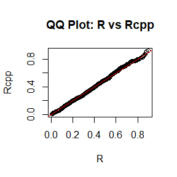

```r
# 参数设置
n <- 10
a <- 2
b <- 3
N <- 1000

# 生成样本
set.seed(123)
r_samples <- gibbs_sampler_r(n, a, b, N)
rcpp_samples <- gibbs_sampler_rcpp(n, a, b, N)

# 比较 y 的分布
qqplot(r_samples$y, rcpp_samples$y, main = "QQ Plot: R vs Rcpp", xlab = "R", ylab = "Rcpp")
abline(0, 1, col = "red")
```

点大部分沿着对角线 $ y=x $ 排列，说明两组数据的分布非常相似.此图表明，R 和 Rcpp 两种方法生成的随机数分布是高度一致的

## 比较运行时间

用 microbenchmark 比较两种实现的效率：

```r
library(microbenchmark)

benchmark_result <- microbenchmark(
  R = gibbs_sampler_r(n, a, b, N),
  Rcpp = gibbs_sampler_rcpp(n, a, b, N),
  times = 100
)
print(benchmark_result)
```

```
## Unit: microseconds
##  expr    min      lq     mean  median      uq    max neval cld
##     R 2374.6 2452.75 3065.641 2554.55 3220.45 8089.3   100  a
##  Rcpp  396.3  412.45  582.835  432.35  640.50 2108.8   100   b
```

### 结论

从 microbenchmark 的结果可以得出以下结论： 可以看到，Rcpp 的运行速度大约是 R 实现的6倍。使用 Rcpp 明显加速了计算。C++ 的高性能数值计算能力，以及对循环和随机数生成的优化，使得其在高密度计算（如 Gibbs 采样）中表现更优。 Rcpp 实现比 R 的运行时间更稳定，max 和 min 的差距较小，表明 Rcpp 在多次运行中性能波动较低。 而 R 实现的波动更大，max 和 min 的差距显著。

对两种方法的评估：

- R 实现：适合快速原型设计、小规模计算或对性能要求不高的任务。
- Rcpp 实现：适合大规模计算、高性能需求的任务，特别是在迭代次数较多或样本量很大的场景。在性能上具有显著优势，可以极大地提升效率，使得代码运行更快且更稳定。